# Исследование: Прогноз активности покупателей интернет-магазина

#### Полиномизация и сэмплирование признаков

Отталкиваясь от лучшей найденной модели, попробуем еще ее немного улучшить с помощью полиномизация признаков и устранения дизбаланса классов методом SMOTE. Также попробуем разные ядра.

Параметров немного, поэтому используем полный перебор GridSearchCV.

```python
param_grid_svc = [
    {
        'models': [best_optuna_model.named_steps['models']],
        'poly': [PolynomialFeatures(include_bias=False), 'passthrough'],
        'sampler': [SMOTE(random_state=RANDOM_STATE), 'passthrough'],
        'models__kernel': ['linear', 'rbf']
    }

]
```

```
Лучшая модель и её параметры:
```

```
Pipeline(steps=[('preprocessor',
                 ColumnTransformer(remainder='passthrough',
                                   transformers=[('ohe',
                                                  Pipeline(steps=[('simpleImputer_ohe',
                                                                   SimpleImputer(strategy='most_frequent')),
                                                                  ('ohe',
                                                                   OneHotEncoder(drop='first',
                                                                                 sparse_output=False))]),
                                                  ['тип_сервиса',
                                                   'разрешить_сообщать',
                                                   'популярная_категория']),
                                                 ('ord',
                                                  Pipeline(steps=[('simpleImputer_before_ord',
                                                                   SimpleI...
                                                   'неоплаченные_продукты_штук_квартал',
                                                   'ошибка_сервиса',
                                                   'страниц_за_визит',
                                                   'препредыдущий_месяц_выручка',
                                                   'предыдущий_месяц_выручка',
                                                   'текущий_месяц_выручка',
                                                   'предыдущий_месяц_минут',
                                                   'текущий_месяц_минут'])])),
                ('poly', 'passthrough'), ('sampler', 'passthrough'),
                ('models',
                 SVC(C=89.31066986758924, gamma=0.2701807036080126,
                     probability=True, random_state=42))])
```

```
Метрика лучшей модели ROC-AUC на кросс-валидации (тренировочная выборка): 0.9150132506261286
Метрика ROC-AUC на валидационной выборке: 0.9131313131313131
```

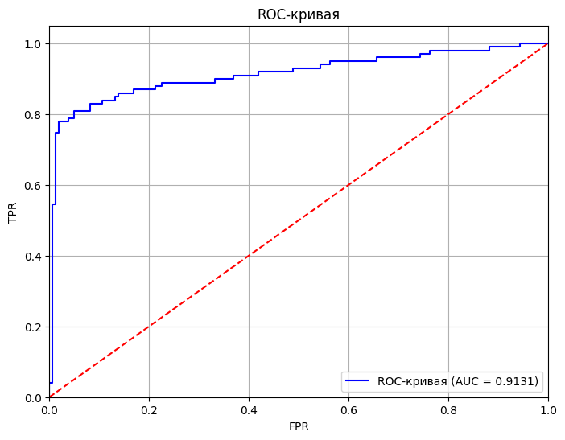

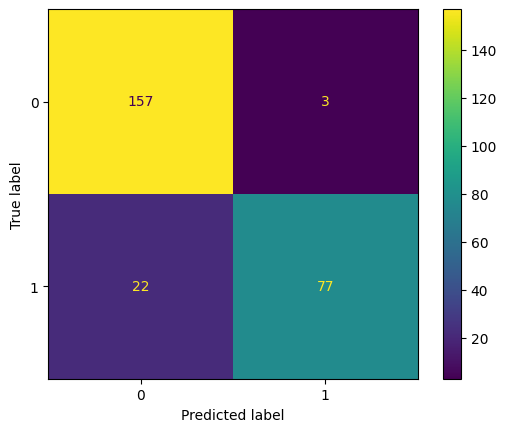

|  | rank_test_score | param_models | mean_test_score | params |
| --- | --- | --- | --- | --- |
| 7 | 1 | SVC(C=89.31066986758924, gamma=0.2701807036080... | 0.915013 | {'models': SVC(C=89.31066986758924, gamma=0.27... |
| 6 | 2 | SVC(C=89.31066986758924, gamma=0.2701807036080... | 0.913832 | {'models': SVC(C=89.31066986758924, gamma=0.27... |
| 3 | 3 | SVC(C=89.31066986758924, gamma=0.2701807036080... | 0.893890 | {'models': SVC(C=89.31066986758924, gamma=0.27... |
| 2 | 4 | SVC(C=89.31066986758924, gamma=0.2701807036080... | 0.891717 | {'models': SVC(C=89.31066986758924, gamma=0.27... |
| 1 | 5 | SVC(C=89.31066986758924, gamma=0.2701807036080... | 0.845796 | {'models': SVC(C=89.31066986758924, gamma=0.27... |

```
CPU times: user 759 ms, sys: 224 ms, total: 983 ms
Wall time: 25.9 s
```

```python
%%time

grid_search_svc, results = find_best_model_grid(
    pipe_final_imb,
    param_grid_svc
)
print()
```

Лучшая можель по прежнему та же, что была выбрана ранее. Полиномизация и сэмплирование не пригодилось. Попробуем еще полиномиальное ядро с разными степенями.

```python
# Сохраним результаты в соответствующие списки
pipelines_names.append('grid_search_svc.best_estimator_')  # Сохраняем имя модели
pipelines.append(grid_search_svc.best_estimator_)       # Сохраняем саму модель

# Получаем AUC
train_auc_cv.append(grid_search_svc.best_score_)
valid_auc.append(roc_auc_score(y_valid, grid_search_svc.best_estimator_.predict_proba(X_valid)[:,1]))
```

```python
param_grid_svc_poly = [
    {
        'models': [best_optuna_model.named_steps['models']],
        'poly': [PolynomialFeatures(include_bias=False), 'passthrough'],
        'sampler': [SMOTE(random_state=RANDOM_STATE), 'passthrough'],
        'models__kernel': ['poly'],  # Используем только полиномиальное ядро
        'models__degree': range(2, 6)  # Добавляем степени для полиномиального ядра
    }
]
```

```
Лучшая модель и её параметры:
```

```
Pipeline(steps=[('preprocessor',
                 ColumnTransformer(remainder='passthrough',
                                   transformers=[('ohe',
                                                  Pipeline(steps=[('simpleImputer_ohe',
                                                                   SimpleImputer(strategy='most_frequent')),
                                                                  ('ohe',
                                                                   OneHotEncoder(drop='first',
                                                                                 sparse_output=False))]),
                                                  ['тип_сервиса',
                                                   'разрешить_сообщать',
                                                   'популярная_категория']),
                                                 ('ord',
                                                  Pipeline(steps=[('simpleImputer_before_ord',
                                                                   SimpleI...
                                                   'страниц_за_визит',
                                                   'препредыдущий_месяц_выручка',
                                                   'предыдущий_месяц_выручка',
                                                   'текущий_месяц_выручка',
                                                   'предыдущий_месяц_минут',
                                                   'текущий_месяц_минут'])])),
                ('poly', PolynomialFeatures(include_bias=False)),
                ('sampler', SMOTE(random_state=42)),
                ('models',
                 SVC(C=89.31066986758924, degree=2, gamma=0.2701807036080126,
                     kernel='poly', probability=True, random_state=42))])
```

```
Метрика лучшей модели ROC-AUC на кросс-валидации (тренировочная выборка): 0.8801493243636788
Метрика ROC-AUC на валидационной выборке: 0.875189393939394
```

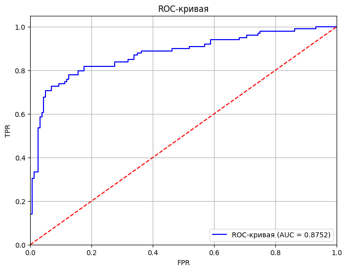

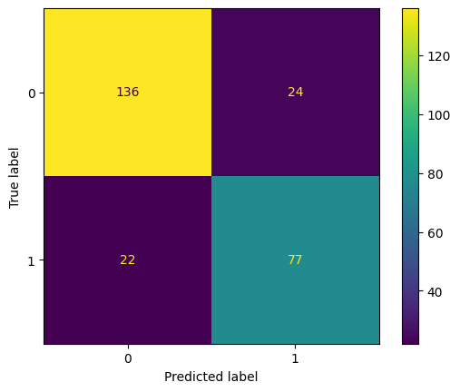

|  | rank_test_score | param_models | mean_test_score | params |
| --- | --- | --- | --- | --- |
| 0 | 1 | SVC(C=89.31066986758924, gamma=0.2701807036080... | 0.880149 | {'models': SVC(C=89.31066986758924, gamma=0.27... |
| 1 | 2 | SVC(C=89.31066986758924, gamma=0.2701807036080... | 0.880050 | {'models': SVC(C=89.31066986758924, gamma=0.27... |
| 15 | 3 | SVC(C=89.31066986758924, gamma=0.2701807036080... | 0.878440 | {'models': SVC(C=89.31066986758924, gamma=0.27... |
| 6 | 4 | SVC(C=89.31066986758924, gamma=0.2701807036080... | 0.873382 | {'models': SVC(C=89.31066986758924, gamma=0.27... |
| 14 | 5 | SVC(C=89.31066986758924, gamma=0.2701807036080... | 0.872393 | {'models': SVC(C=89.31066986758924, gamma=0.27... |

```
CPU times: user 912 ms, sys: 191 ms, total: 1.1 s
Wall time: 11.8 s
```

```python
%%time

grid_search_svc_poly, results = find_best_model_grid(
    pipe_final_imb,
    param_grid_svc_poly
)
print()
```

```python
# Сохраним результаты в соответствующие списки
pipelines_names.append('grid_search_svc_poly.best_estimator_')  # Сохраняем имя модели
pipelines.append(grid_search_svc_poly.best_estimator_)       # Сохраняем саму модель

# Получаем AUC
train_auc_cv.append(grid_search_svc_poly.best_score_)
valid_auc.append(roc_auc_score(y_valid, grid_search_svc_poly.best_estimator_.predict_proba(X_valid)[:,1]))
```

Полономинальное ядро отработало хуже. Оставим предыдущий варинт.

### Селектор признаков

```python
# обновим пайплайн и добавим в него отбор признаков
pipe_final_imb_selector = ImbPipeline([
    ('preprocessor', data_preprocessor),
    ('selector', 'passthrough'),
    ('models', LogisticRegression(random_state=RANDOM_STATE))
])
```

```python
len(best_optuna_model.named_steps['preprocessor'].get_feature_names_out())
```

```
20
```

```python
param_grid_svc_selector = [
    {
        'models': [best_optuna_model.named_steps['models']],
        'selector' : [SelectKBest(score_func=f_classif), SelectKBest(score_func=mutual_info_classif)],
        'selector__k': range(1, len(best_optuna_model.named_steps['preprocessor'].get_feature_names_out()))
    }

]
```

```
Лучшая модель и её параметры:
```

```
Pipeline(steps=[('preprocessor',
                 ColumnTransformer(remainder='passthrough',
                                   transformers=[('ohe',
                                                  Pipeline(steps=[('simpleImputer_ohe',
                                                                   SimpleImputer(strategy='most_frequent')),
                                                                  ('ohe',
                                                                   OneHotEncoder(drop='first',
                                                                                 sparse_output=False))]),
                                                  ['тип_сервиса',
                                                   'разрешить_сообщать',
                                                   'популярная_категория']),
                                                 ('ord',
                                                  Pipeline(steps=[('simpleImputer_before_ord',
                                                                   SimpleI...
                                                   'ошибка_сервиса',
                                                   'страниц_за_визит',
                                                   'препредыдущий_месяц_выручка',
                                                   'предыдущий_месяц_выручка',
                                                   'текущий_месяц_выручка',
                                                   'предыдущий_месяц_минут',
                                                   'текущий_месяц_минут'])])),
                ('selector',
                 SelectKBest(k=17,
                             score_func=<function mutual_info_classif at 0x7c5a407a98a0>)),
                ('models',
                 SVC(C=89.31066986758924, gamma=0.2701807036080126,
                     probability=True, random_state=42))])
```

```
Метрика лучшей модели ROC-AUC на кросс-валидации (тренировочная выборка): 0.9133079362999202
Метрика ROC-AUC на валидационной выборке: 0.9077020202020202
```

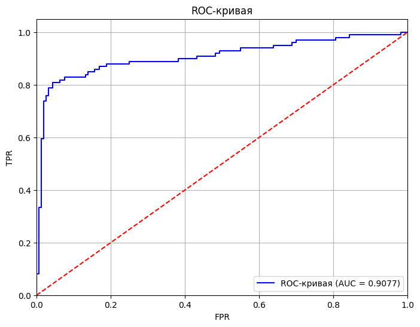

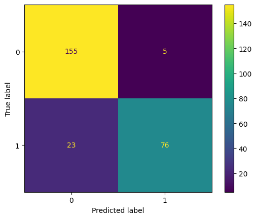

|  | rank_test_score | param_models | mean_test_score | params |
| --- | --- | --- | --- | --- |
| 35 | 1 | SVC(C=89.31066986758924, gamma=0.2701807036080... | 0.913308 | {'models': SVC(C=89.31066986758924, gamma=0.27... |
| 18 | 2 | SVC(C=89.31066986758924, gamma=0.2701807036080... | 0.912463 | {'models': SVC(C=89.31066986758924, gamma=0.27... |
| 36 | 3 | SVC(C=89.31066986758924, gamma=0.2701807036080... | 0.911853 | {'models': SVC(C=89.31066986758924, gamma=0.27... |
| 17 | 4 | SVC(C=89.31066986758924, gamma=0.2701807036080... | 0.910566 | {'models': SVC(C=89.31066986758924, gamma=0.27... |
| 15 | 5 | SVC(C=89.31066986758924, gamma=0.2701807036080... | 0.910489 | {'models': SVC(C=89.31066986758924, gamma=0.27... |

```
CPU times: user 1.08 s, sys: 199 ms, total: 1.28 s
Wall time: 18.8 s
```

```python
%%time

grid_search_svc_selector, results = find_best_model_grid(
    pipe_final_imb_selector,
    param_grid_svc_selector
)
print()
```

```python
# Сохраним результаты в соответствующие списки
pipelines_names.append('grid_search_svc_selector.best_estimator_')  # Сохраняем имя модели
pipelines.append(grid_search_svc_selector.best_estimator_)       # Сохраняем саму модель

# Получаем AUC
train_auc_cv.append(grid_search_svc_selector.best_score_)
valid_auc.append(roc_auc_score(y_valid, grid_search_svc_selector.best_estimator_.predict_proba(X_valid)[:,1]))
```

### Dummy-модели

Для сравнения проверим, как поведут себя различные примитивные модели и какие предсказания они дадут. Выберем из них лучшую и запишем в общую таблицу для сравнения.

```python
param_grid_dummy = [
    {
        'models': [DummyClassifier(random_state=RANDOM_STATE)],
        'models__strategy': ['most_frequent', 'prior', 'stratified', 'uniform'],
    },
    {
        'models': [DummyClassifier(random_state=RANDOM_STATE, strategy='constant')],
        'models__constant': [0]
    }
]
```

```
Лучшая модель и её параметры:
```

```
Pipeline(steps=[('preprocessor',
                 ColumnTransformer(remainder='passthrough',
                                   transformers=[('ohe',
                                                  Pipeline(steps=[('simpleImputer_ohe',
                                                                   SimpleImputer(strategy='most_frequent')),
                                                                  ('ohe',
                                                                   OneHotEncoder(drop='first',
                                                                                 sparse_output=False))]),
                                                  ['тип_сервиса',
                                                   'разрешить_сообщать',
                                                   'популярная_категория']),
                                                 ('ord',
                                                  Pipeline(steps=[('simpleImputer_before_ord',
                                                                   SimpleI...
                                                   'маркет_актив_тек_мес',
                                                   'длительность',
                                                   'средний_просмотр_категорий_за_визит',
                                                   'неоплаченные_продукты_штук_квартал',
                                                   'ошибка_сервиса',
                                                   'страниц_за_визит',
                                                   'препредыдущий_месяц_выручка',
                                                   'предыдущий_месяц_выручка',
                                                   'текущий_месяц_выручка',
                                                   'предыдущий_месяц_минут',
                                                   'текущий_месяц_минут'])])),
                ('models',
                 DummyClassifier(random_state=42, strategy='most_frequent'))])
```

```
Метрика лучшей модели ROC-AUC на кросс-валидации (тренировочная выборка): 0.5
Метрика ROC-AUC на валидационной выборке: 0.5
```

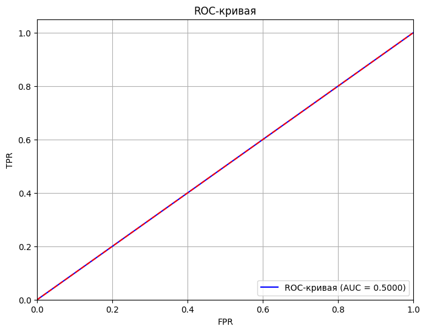

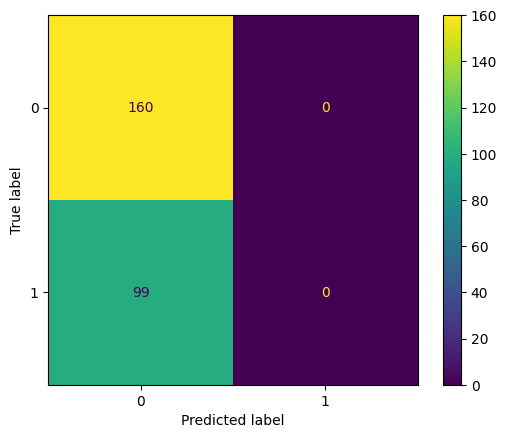

|  | rank_test_score | param_models | mean_test_score | params |
| --- | --- | --- | --- | --- |
| 0 | 1 | DummyClassifier(random_state=42) | 0.500000 | {'models': DummyClassifier(random_state=42), '... |
| 1 | 1 | DummyClassifier(random_state=42) | 0.500000 | {'models': DummyClassifier(random_state=42), '... |
| 3 | 1 | DummyClassifier(random_state=42) | 0.500000 | {'models': DummyClassifier(random_state=42), '... |
| 4 | 1 | DummyClassifier(random_state=42, strategy='con... | 0.500000 | {'models': DummyClassifier(random_state=42, st... |
| 2 | 5 | DummyClassifier(random_state=42) | 0.467459 | {'models': DummyClassifier(random_state=42), '... |

```
CPU times: user 472 ms, sys: 130 ms, total: 603 ms
Wall time: 958 ms
```

```python
%%time

grid_search_dummy, results_dummy = find_best_model_grid(
    pipe_final,
    param_grid_dummy
)
print()
```

Dummy-модель со стратегией 'most_frequent' показала лучший результат. Во всех случая она предсказывала неизменность активности пользователей.

```python
# Сохраним результаты в соответствующие списки
pipelines_names.append('grid_search_dummy.best_estimator_')  # Сохраняем имя модели
pipelines.append(grid_search_dummy.best_estimator_)       # Сохраняем саму модель

# Получаем AUC
train_auc_cv.append(grid_search_dummy.best_score_)
valid_auc.append(roc_auc_score(y_valid, grid_search_dummy.best_estimator_.predict_proba(X_valid)[:,1]))
```

### Лучшая модель

Соберем статистику по обученным моделям в таблицу и выберем модель, которая лучше всего показала себя на тренировочной выборке.

```python
aggregated_stats = pd.DataFrame({
    'Модель': [pipeline.named_steps['models'] for pipeline in pipelines],
    'Обученный пайплайн': pipelines,
    'Пайплай хранится в переменной': pipelines_names,
    'ROC_AUC_CV (тренировочная)': train_auc_cv,
    'ROC_AUC (валидационная)': valid_auc
})
```

```python
# Создадим маски для максимума и второго максимума
mask_max = aggregated_stats['ROC_AUC_CV (тренировочная)'] == aggregated_stats['ROC_AUC_CV (тренировочная)'].max()
mask_second_max = aggregated_stats['ROC_AUC_CV (тренировочная)'] == aggregated_stats['ROC_AUC_CV (тренировочная)'].nlargest(2).iloc[-1]

# Функция для применения стилей
def highlight_max_and_second_max(s, mask_max, mask_second_max):
    styles = ['' for _ in range(len(s))]
    if mask_max.any():
        styles[mask_max.argmax()] = 'background-color: green'  # Максимум
    if mask_second_max.any():
        styles[mask_second_max.argmax()] = 'background-color: yellow'  # Второй максимум
    return styles

# Применим стилизацию
aggregated_stats_styled = aggregated_stats.style.apply(
    highlight_max_and_second_max,
    mask_max=mask_max,
    mask_second_max=mask_second_max,
    axis=0
)

# Отобразим стилизованный DataFrame
aggregated_stats_styled
```

|  | Модель | Обученный пайплайн | Пайплай хранится в переменной | ROC_AUC_CV (тренировочная) | ROC_AUC (валидационная) |
| --- | --- | --- | --- | --- | --- |
| 0 | LogisticRegression(random_state=42) | Pipeline(steps=[('preprocessor', ColumnTransformer(remainder='passthrough', transformers=[('ohe', Pipeline(steps=[('simpleImputer_ohe', SimpleImputer(strategy='most_frequent')), ('ohe', OneHotEncoder(… | base_model | 0.893879 | 0.927146 |
| 1 | DecisionTreeClassifier(max_depth=10, min_samples_leaf=15, min_samples_split=19, random_state=42) | Pipeline(steps=[('preprocessor', ColumnTransformer(remainder='passthrough', transformers=[('ohe', Pipeline(steps=[('simpleImputer_ohe', SimpleImputer(strategy='most_frequent')), ('ohe', OneHotEncoder(… | randomized_search.best_estimator_ | 0.883639 | 0.892992 |
| 2 | DecisionTreeClassifier(max_depth=14, min_samples_leaf=10, min_samples_split=20, random_state=42) | Pipeline(steps=[('preprocessor', ColumnTransformer(remainder='passthrough', transformers=[('ohe', Pipeline(steps=[('simpleImputer_ohe', SimpleImputer(strategy='most_frequent')), ('ohe', OneHotEncoder(… | optuna_models_dict['DecisionTreeClassifier'] | 0.883203 | 0.894539 |
| 3 | KNeighborsClassifier(n_neighbors=20) | Pipeline(steps=[('preprocessor', ColumnTransformer(remainder='passthrough', transformers=[('ohe', Pipeline(steps=[('simpleImputer_ohe', SimpleImputer(strategy='most_frequent')), ('ohe', OneHotEncoder(… | optuna_models_dict['KNeighborsClassifier'] | 0.894139 | 0.904924 |
| 4 | LogisticRegression(C=9.05173001043461, penalty='l1', random_state=42, solver='liblinear') | Pipeline(steps=[('preprocessor', ColumnTransformer(remainder='passthrough', transformers=[('ohe', Pipeline(steps=[('simpleImputer_ohe', SimpleImputer(strategy='most_frequent')), ('ohe', OneHotEncoder(… | optuna_models_dict['LogisticRegression'] | 0.894641 | 0.926389 |
| 5 | SVC(C=89.31066986758924, gamma=0.2701807036080126, probability=True, random_state=42) | Pipeline(steps=[('preprocessor', ColumnTransformer(remainder='passthrough', transformers=[('ohe', Pipeline(steps=[('simpleImputer_ohe', SimpleImputer(strategy='most_frequent')), ('ohe', OneHotEncoder(… | optuna_models_dict['SVC'] | 0.915013 | 0.913131 |
| 6 | SVC(C=89.31066986758924, gamma=0.2701807036080126, probability=True, random_state=42) | Pipeline(steps=[('preprocessor', ColumnTransformer(remainder='passthrough', transformers=[('ohe', Pipeline(steps=[('simpleImputer_ohe', SimpleImputer(strategy='most_frequent')), ('ohe', OneHotEncoder(… | grid_search_svc.best_estimator_ | 0.915013 | 0.913131 |
| 7 | SVC(C=89.31066986758924, degree=2, gamma=0.2701807036080126, kernel='poly', probability=True, random_state=42) | Pipeline(steps=[('preprocessor', ColumnTransformer(remainder='passthrough', transformers=[('ohe', Pipeline(steps=[('simpleImputer_ohe', SimpleImputer(strategy='most_frequent')), ('ohe', OneHotEncoder(… | grid_search_svc_poly.best_estimator_ | 0.880149 | 0.875189 |
| 8 | SVC(C=89.31066986758924, gamma=0.2701807036080126, probability=True, random_state=42) | Pipeline(steps=[('preprocessor', ColumnTransformer(remainder='passthrough', transformers=[('ohe', Pipeline(steps=[('simpleImputer_ohe', SimpleImputer(strategy='most_frequent')), ('ohe', OneHotEncoder(… | grid_search_svc_selector.best_estimator_ | 0.913308 | 0.907702 |
| 9 | DummyClassifier(random_state=42, strategy='most_frequent') | Pipeline(steps=[('preprocessor', ColumnTransformer(remainder='passthrough', transformers=[('ohe', Pipeline(steps=[('simpleImputer_ohe', SimpleImputer(strategy='most_frequent')), ('ohe', OneHotEncoder(… | grid_search_dummy.best_estimator_ | 0.500000 | 0.500000 |

Лучшая модель SVC, с соответствующими параметрами, была найдена с помощью OptunaSearchCV (выделена желтым цветом в таблице).

Для дальнейшего анализа в качестве лучшей модели будем использовать исходную SVC модель (выделена желтым в таблице), т.к. предположительно она должна работь более устойчиво.

```python
# Запишем лучшую модель в переменную
best_model = optuna_models_dict['SVC']
```

Посмотрим, как покажет себя выбранная модель на тестовой выборке.

[output not shown]

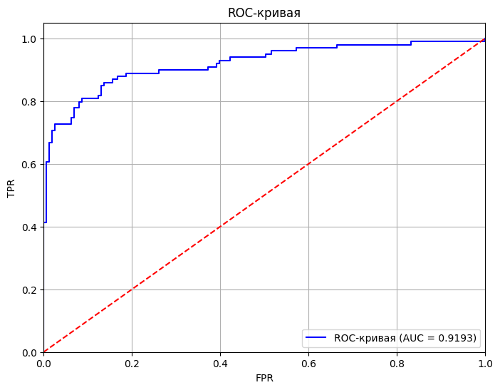

[output not shown]

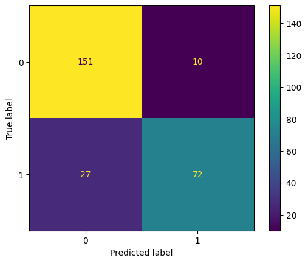

[output not shown]

```python
y_valid_pred = best_model.predict(X_valid)
y_valid_proba = best_model.predict_proba(X_valid)[:, 1]

y_test_pred = best_model.predict(X_test)
y_test_proba = best_model.predict_proba(X_test)[:, 1]


# Построение ROC кривой и матрицы ошибок
print("Матрица ошибок на тестовой выборке")
plot_roc_curve(y_test, y_test_proba)
print("График ROC-AUC на тестовой выборке")
plot_confusion_matrix(best_model, X_test, y_test)

print(f'Метрика ROC-AUC на кросс-валидации (тренировочная выборка): {cross_val_score(best_model, X_train, y_train, cv=5, scoring="roc_auc").mean()}')
print(f'Метрика ROC-AUC на валидационной выборке: {roc_auc_score(y_valid, y_valid_proba)}')
print(f'Метрика ROC-AUC на тренировочной выборке: {roc_auc_score(y_test, y_test_proba)}')
```

Видим, что метрики на всех трех выборках почти совпадают, значит модель работает устойчиво.

Попробуем посмотреть, получится ли максимизировать Recall не потеряв в качестве модели.

```
Best threshold: 0.0
Accuracy: 0.38076923076923075
Recall: 1.0
Precision: 0.38076923076923075
ROC AUC: 0.9193173975782671
```

|  | Порог | Accuracy | Precision | Recall | Количество «правильных единичек» | Количество False Positive | Количество False Negative | Количество "правильных нулей" |
| --- | --- | --- | --- | --- | --- | --- | --- | --- |
| 0 | y_pred_0.000 | 0.380769 | 0.380769 | 1.000000 | 99 | 161 | 0 | 0 |
| 1 | y_pred_0.010 | 0.392308 | 0.384314 | 0.989899 | 98 | 157 | 1 | 4 |
| 2 | y_pred_0.020 | 0.446154 | 0.406639 | 0.989899 | 98 | 143 | 1 | 18 |
| 3 | y_pred_0.030 | 0.484615 | 0.423581 | 0.979798 | 97 | 132 | 2 | 29 |
| 4 | y_pred_0.040 | 0.515385 | 0.438914 | 0.979798 | 97 | 124 | 2 | 37 |
| ... | ... | ... | ... | ... | ... | ... | ... | ... |
| 95 | y_pred_0.960 | 0.761538 | 1.000000 | 0.373737 | 37 | 0 | 62 | 161 |
| 96 | y_pred_0.970 | 0.742308 | 1.000000 | 0.323232 | 32 | 0 | 67 | 161 |
| 97 | y_pred_0.980 | 0.723077 | 1.000000 | 0.272727 | 27 | 0 | 72 | 161 |
| 98 | y_pred_0.990 | 0.684615 | 1.000000 | 0.171717 | 17 | 0 | 82 | 161 |
| 99 | y_pred_1.000 | 0.619231 | 1.000000 | 0.000000 | 0 | 0 | 99 | 161 |

100 rows × 8 columns

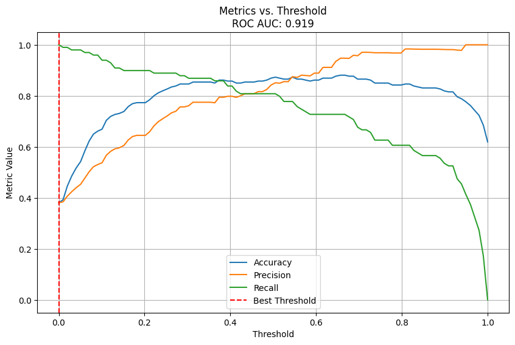

```python
best_threshold, best_precision, results_df = find_optimal_threshold_recall(best_model, X_test, y_test, num=100)
```

Видно, что максимальный Recall достигается при пороге классификации 0%, что эквивалентно просто проставлению моделью всем предсказанным значениям предсказаного класса 1 (активность уменьшилась). Это противоречит первоначальной задаче по выделению целевого сегмента для направления персонализированной рекламы. Получается, что персонализированную рекламу придется направлять всем клиентам.

В целом, метрики первоначальной модели с порогом классификации 50% удовлетворительные, не будем их менять и оставим модель как есть.

### Выводы

1. **Подготовка данных:**
- Исходная выборка была разбита на три: тренировочную, валидационную и тестовую в пропорции: 3-1-1 (60%-20%-20%)
- Целевая переменная была закодирована с помощью LabelEncoder.
- Категориальные признаки были закодированы OneHotEncoder и OrdinalEncoder (ранговые).
- Для масштабирования данных использовались: StandardScaler() и MinMaxScaler().
2. **Сборка пайплайна, подбор моделей и гиперпараметров:**
- Был создан пайплайн, для обработки данных, обучения моделей и получения предсказаний.
- Выбор лучшей модели производился из: KNeighborsClassifier(), DecisionTreeClassifier(), LogisticRegression(), SVC(), DummyClassifier().
- Для перебора моделей и гиперпараметров были использованы: RandomizedSearchCV(), GridSearchCV(), OptunaSearchCV().
- В результате поиска в качестве самой лучшей модели была выбрана модель со следующими параметрами:

```python
print(aggregated_stats.loc[5, "Модель"])
print(f'ROC_AUC_CV (тренировочная): {round(aggregated_stats.loc[5, "ROC_AUC_CV (тренировочная)"], 4)}')
print(f'ROC_AUC (валидационная): {round(aggregated_stats.loc[5, "ROC_AUC (валидационная)"], 4)}')
print(f'ROC_AUC (тестовая): {round(roc_auc_score(y_test, y_test_proba), 4)}')
```

```
SVC(C=89.31066986758924, gamma=0.2701807036080126, probability=True,
    random_state=42)
ROC_AUC_CV (тренировочная): 0.915
ROC_AUC (валидационная): 0.9131
ROC_AUC (тестовая): 0.9193
```

3. **Дальнейшее улучшение модели:**
- Для дальнейшего улучшения выбранной модели были попробованы:
- Полиномизация признаков с помощью PolynomialFeatures();
- Сэмплирование (устранение дизбаланса целевого класса) с помощью SMOTE().
- Сэмплирование и полиномизация не улучшили качество модели.
- Была сделана попытка подобрать порог классификации для минимизации ложноотрицательной ошибки (максимизации Recall), однако максимальное значение метрики Recall достигалось на пороге классификации 0%. При таком пороге всем пользователям предсказывалось бы снижение активности, что делает модель бессмысленной. Поэтому порог классификации был оставлен без изменений.

## Анализ важности признаков лучшей модели

### SHAP

Оценим важность признаков для лучшей модели с помощью метода SHAP.

```python
best_preprocessor = best_model.named_steps['preprocessor']
models = best_model.named_steps['models']
```

```python
feature_names = best_preprocessor.get_feature_names_out()
```

```python
# Обработка данных
X_train_processed = best_preprocessor.fit_transform(X_train)
X_test_processed = best_preprocessor.transform(X_test)

# Преобразование обратно в DataFrame с сохранением названий колонок
X_train_processed = pd.DataFrame(X_train_processed, columns=best_preprocessor.get_feature_names_out())
X_test_processed = pd.DataFrame(X_test_processed, columns=best_preprocessor.get_feature_names_out())

# Проверка результатов
display(X_train_processed.head())
display(X_test_processed.head())
```

|  | ohe__тип_сервиса_стандарт | ohe__разрешить_сообщать_нет | ohe__популярная_категория_косметика и аксесуары | ohe__популярная_категория_кухонная посуда | ohe__популярная_категория_мелкая бытовая техника и электроника | ohe__популярная_категория_техника для красоты и здоровья | ohe__популярная_категория_товары для детей | ord__акционные_покупки_категория | num__маркет_актив_6_мес | num__маркет_актив_тек_мес | num__длительность | num__средний_просмотр_категорий_за_визит | num__неоплаченные_продукты_штук_квартал | num__ошибка_сервиса | num__страниц_за_визит | num__препредыдущий_месяц_выручка | num__предыдущий_месяц_выручка | num__текущий_месяц_выручка | num__предыдущий_месяц_минут | num__текущий_месяц_минут |
| --- | --- | --- | --- | --- | --- | --- | --- | --- | --- | --- | --- | --- | --- | --- | --- | --- | --- | --- | --- | --- |
| 0 | 1.0 | 0.0 | 0.0 | 1.0 | 0.0 | 0.0 | 0.0 | 0.0 | 1.528009 | -1.429866 | -1.057681 | 1.284134 | -0.935931 | -1.129944 | -0.322557 | 0.881455 | -1.118709 | -2.159349 | -0.376414 | 1.420356 |
| 1 | 1.0 | 0.0 | 0.0 | 0.0 | 0.0 | 0.0 | 0.0 | 0.0 | -1.641460 | -1.429866 | 1.019609 | -0.944694 | -0.935931 | -0.102482 | 0.916942 | 0.717127 | 0.502791 | 0.448909 | 0.641771 | 0.453543 |
| 2 | 1.0 | 1.0 | 0.0 | 0.0 | 0.0 | 1.0 | 0.0 | 0.0 | -0.155771 | 1.397121 | -0.829540 | 0.541191 | -0.935931 | 1.438711 | -0.570457 | 0.030470 | -0.620282 | -0.368317 | 0.387225 | -1.721785 |
| 3 | 1.0 | 0.0 | 0.0 | 1.0 | 0.0 | 0.0 | 0.0 | 0.0 | 0.141367 | 1.397121 | -1.393890 | -1.687637 | 1.573448 | -1.643675 | -1.562057 | -2.094060 | -0.053725 | -0.425102 | -1.140052 | -0.271566 |
| 4 | 1.0 | 0.0 | 1.0 | 0.0 | 0.0 | 0.0 | 0.0 | 0.0 | 0.438504 | -0.016373 | -0.401274 | -0.201751 | -0.434055 | -0.102482 | 0.669043 | 1.262932 | -0.420194 | -1.197141 | 2.169048 | 0.453543 |

|  | ohe__тип_сервиса_стандарт | ohe__разрешить_сообщать_нет | ohe__популярная_категория_косметика и аксесуары | ohe__популярная_категория_кухонная посуда | ohe__популярная_категория_мелкая бытовая техника и электроника | ohe__популярная_категория_техника для красоты и здоровья | ohe__популярная_категория_товары для детей | ord__акционные_покупки_категория | num__маркет_актив_6_мес | num__маркет_актив_тек_мес | num__длительность | num__средний_просмотр_категорий_за_визит | num__неоплаченные_продукты_штук_квартал | num__ошибка_сервиса | num__страниц_за_визит | num__препредыдущий_месяц_выручка | num__предыдущий_месяц_выручка | num__текущий_месяц_выручка | num__предыдущий_месяц_минут | num__текущий_месяц_минут |
| --- | --- | --- | --- | --- | --- | --- | --- | --- | --- | --- | --- | --- | --- | --- | --- | --- | --- | --- | --- | --- |
| 0 | 0.0 | 0.0 | 0.0 | 0.0 | 0.0 | 1.0 | 0.0 | 0.0 | 0.141367 | -0.016373 | 1.511915 | -0.201751 | -0.935931 | 1.952442 | -0.570457 | 0.265224 | -2.476294 | -1.295609 | -0.885506 | -0.996676 |
| 1 | 1.0 | 1.0 | 0.0 | 0.0 | 0.0 | 0.0 | 1.0 | 0.0 | -0.254817 | 1.397121 | 1.011604 | -0.944694 | 2.075324 | 0.924980 | -0.818357 | -1.565862 | 0.940259 | 0.982328 | -0.885506 | -1.238379 |
| 2 | 1.0 | 0.0 | 0.0 | 0.0 | 0.0 | 0.0 | 0.0 | 0.0 | 1.230872 | -1.429866 | -0.545363 | 2.027076 | -0.935931 | -0.616213 | 0.421143 | -0.512400 | -0.326246 | -0.415920 | -0.121868 | 1.178653 |
| 3 | 1.0 | 0.0 | 0.0 | 0.0 | 1.0 | 0.0 | 0.0 | 0.0 | 0.042321 | 1.397121 | -0.653430 | 0.541191 | -0.935931 | 0.411249 | -0.818357 | -0.465449 | -0.888500 | -1.316752 | 1.405409 | 0.211840 |
| 4 | 0.0 | 1.0 | 0.0 | 1.0 | 0.0 | 0.0 | 0.0 | 0.0 | -0.056725 | -0.016373 | 1.475892 | -0.944694 | -1.437806 | -1.129944 | -0.818357 | 0.981226 | -0.671918 | -1.492424 | 1.150863 | 0.453543 |

```python
# Уменьшаем размер выборки с помощью k-means
n_clusters = 10
kmeans = KMeans(n_clusters=n_clusters, random_state=RANDOM_STATE)
kmeans.fit(X_train_processed)
background_data = kmeans.cluster_centers_

# Создаем объект SHAP Permutation Explainer с уменьшенной выборкой
explainer = shap.PermutationExplainer(best_model.named_steps['models'].decision_function, background_data)

# Рассчитываем значения SHAP
shap_values = explainer(X_test_processed)
```

```
PermutationExplainer explainer: 261it [00:47,  4.55it/s]
```

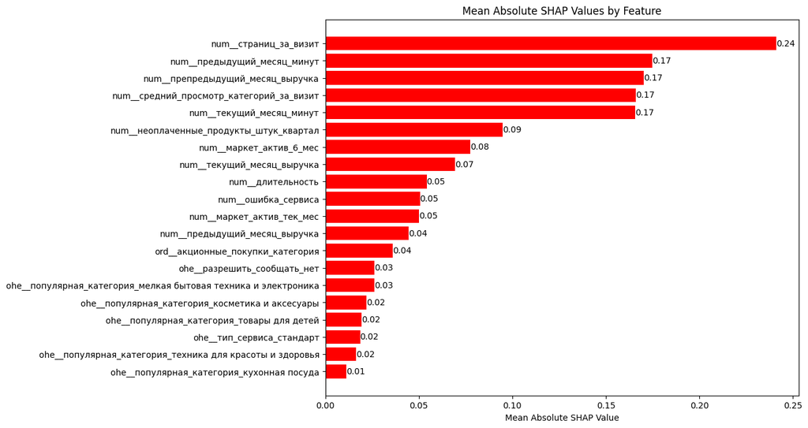

```python
shap_values_array = shap_values.values

# Сортируем абсолютные значения SHAP
mean_shap_values = np.mean(np.abs(shap_values_array), axis=0)
sorted_indices = np.argsort(mean_shap_values)[::-1]

# Пример имен признаков
feature_names = best_preprocessor.get_feature_names_out()

# Создаем график с увеличенной высотой
plt.figure(figsize=(10, 8))  # Увеличена высота графика
bars = plt.barh(np.array(feature_names)[sorted_indices], mean_shap_values[sorted_indices], color='red')
plt.xlabel('Mean Absolute SHAP Value')
plt.title('Mean Absolute SHAP Values by Feature')
plt.axvline(0, color='black', lw=0.8)
plt.gca().invert_yaxis()  # Инвертируем ось Y для правильного порядка

# Добавляем подписи значений
for bar in bars:
    plt.text(bar.get_width(), bar.get_y() + bar.get_height()/2,
             f'{bar.get_width():.2f}',
             va='center')

plt.show()
```

График значений SHAP (Mean Absolute SHAP Values) демонстрирует, как каждый параметр влияет на модель, предсказывающую снижение активности покупателей. Вот основные моменты анализа:

**Параметры со средним влиянием:**

- Параметры, такие `num_неоплаченные_продукты_штук_квартал` (0.09) и `num_маркет_актив_6_мес` (0.08), имеют среднее влияние на предсказания, что значит, что они также важны, но не так критичны, как первые три.

**Низкое влияние:**

- Параметры, такие как `популярная_категория` или `тип_сервис`, имеют минимальное влияние на модель, что может указывать на их незначимость в контексте предсказания активности.

Необходимо сфокусироваться на ключевых параметрах, так как они могут предоставить наиболее ценную информацию для улучшения стратегии взаимодействия с клиентами.

Параметры с низким значением могут быть исключены из модели или требуют дополнительного анализа, чтобы понять, почему они не влияют на предсказания.

```python
# Посмотрим какие категории признаков влияют на предсказания активности пользователя больше всего
shap_values_df = pd.DataFrame(data=[np.array(feature_names)[sorted_indices], mean_shap_values[sorted_indices]],
                              index=['Входящий признак', 'абсолютный SHAP value']).T
shap_values_df['абсолютный SHAP value'] = shap_values_df['абсолютный SHAP value'].astype('float')
```

```python
# Добавим в таблицу категорию признака
feature_groups = {
    "Коммуникация с клиентом": [
        'ohe__тип_сервиса_стандарт',
        'ohe__разрешить_сообщать_нет',
        'num__маркет_актив_6_мес',
        'num__маркет_актив_тек_мес',
        'num__длительность'

    ],
    "Продуктовое поведение": [
        'ohe__популярная_категория_мелкая бытовая техника и электроника',
        'ohe__популярная_категория_техника для красоты и здоровья',
        'ohe__популярная_категория_косметика и аксесуары',
        'ohe__популярная_категория_товары для детей',
        'ohe__популярная_категория_кухонная посуда',
        'ord__акционные_покупки_категория',
        'num__неоплаченные_продукты_штук_квартал',
        'num__средний_просмотр_категорий_за_визит'

    ],
    "Поведение на сайте": [
        'num__текущий_месяц_минут',
        'num__предыдущий_месяц_минут',
        'num__страниц_за_визит',
        'num__ошибка_сервиса'
    ],
    "Финансовое поведение": [
        'num__текущий_месяц_выручка',
        'num__предыдущий_месяц_выручка',
        'num__препредыдущий_месяц_выручка'
    ]
}
```

```python
# Обратный словарь для поиска категорий по признакам
feature_to_category = {feature: category for category, features in feature_groups.items() for feature in features}

# Добавление столбца с категориями
shap_values_df['Категория'] = shap_values_df['Входящий признак'].map(feature_to_category)

shap_values_df
```

|  | Входящий признак | абсолютный SHAP value | Категория |
| --- | --- | --- | --- |
| 0 | num__страниц_за_визит | 0.240925 | Поведение на сайте |
| 1 | num__предыдущий_месяц_минут | 0.174682 | Поведение на сайте |
| 2 | num__препредыдущий_месяц_выручка | 0.170116 | Финансовое поведение |
| 3 | num__средний_просмотр_категорий_за_визит | 0.165894 | Продуктовое поведение |
| 4 | num__текущий_месяц_минут | 0.165767 | Поведение на сайте |
| 5 | num__неоплаченные_продукты_штук_квартал | 0.094859 | Продуктовое поведение |
| 6 | num__маркет_актив_6_мес | 0.077624 | Коммуникация с клиентом |
| 7 | num__текущий_месяц_выручка | 0.069249 | Финансовое поведение |
| 8 | num__длительность | 0.054176 | Коммуникация с клиентом |
| 9 | num__ошибка_сервиса | 0.050588 | Поведение на сайте |
| 10 | num__маркет_актив_тек_мес | 0.049993 | Коммуникация с клиентом |
| 11 | num__предыдущий_месяц_выручка | 0.044606 | Финансовое поведение |
| 12 | ord__акционные_покупки_категория | 0.036164 | Продуктовое поведение |
| 13 | ohe__разрешить_сообщать_нет | 0.026193 | Коммуникация с клиентом |
| 14 | ohe__популярная_категория_мелкая бытовая техни... | 0.026156 | Продуктовое поведение |
| 15 | ohe__популярная_категория_косметика и аксесуары | 0.022088 | Продуктовое поведение |
| 16 | ohe__популярная_категория_товары для детей | 0.019407 | Продуктовое поведение |
| 17 | ohe__тип_сервиса_стандарт | 0.018596 | Коммуникация с клиентом |
| 18 | ohe__популярная_категория_техника для красоты ... | 0.016361 | Продуктовое поведение |
| 19 | ohe__популярная_категория_кухонная посуда | 0.011108 | Продуктовое поведение |

```python
# Найдем сумму коэффициентов abs SHAP values по категориям и нормализуем ее.
(shap_values_df.groupby('Категория')['абсолютный SHAP value'].sum().sort_values(ascending=False) /
    shap_values_df['абсолютный SHAP value'].sum())
```

| Категория | абсолютный SHAP value |
| --- | --- |
| Поведение на сайте | 0.411822 |
| Продуктовое поведение | 0.255473 |
| Финансовое поведение | 0.185051 |
| Коммуникация с клиентом | 0.147654 |

**dtype:** float64

Видим, что больше всего влияет на активность пользователя влияет его поведение на сайте и продуктовое поведение.

Вероятно, что для удержания клиентов нужно сфокусироваться на удержании его на сайте и увеличить просмотр различных категорий товаров. В качестве вариантов увеличения такой активности можно рассмотреть следующие варианты:

**1. Персонализированные рекомендации:** Использовать данные о популярности категорий и предпочтениях пользователей для создания персонализированных страниц с рекомендациями продуктов.

**2. Улучшение навигации:** Оптимизировать структуру сайта, чтобы пользователи могли легко находить интересующие их категории, особенно популярные.

**3. Акции и специальные предложения:** Разработать акции для категорий с высоким интересом пользователей.

**4. Интерактивный контент на сайте:** Внедрить розыгрышы или опросы, чтобы вовлечь пользователей и помочь им выбрать продукты на основе их предпочтений.

**5. Улучшение пользовательского опыта (UX):** Сократить время загрузки страниц и улучшите адаптивность сайта для мобильных устройств, чтобы увеличить время, проведенное пользователями на сайте.

Посмотрим подробней на то, как каждый признак в отдельности влияет на предсказание вероятности снижения активности пользователя.

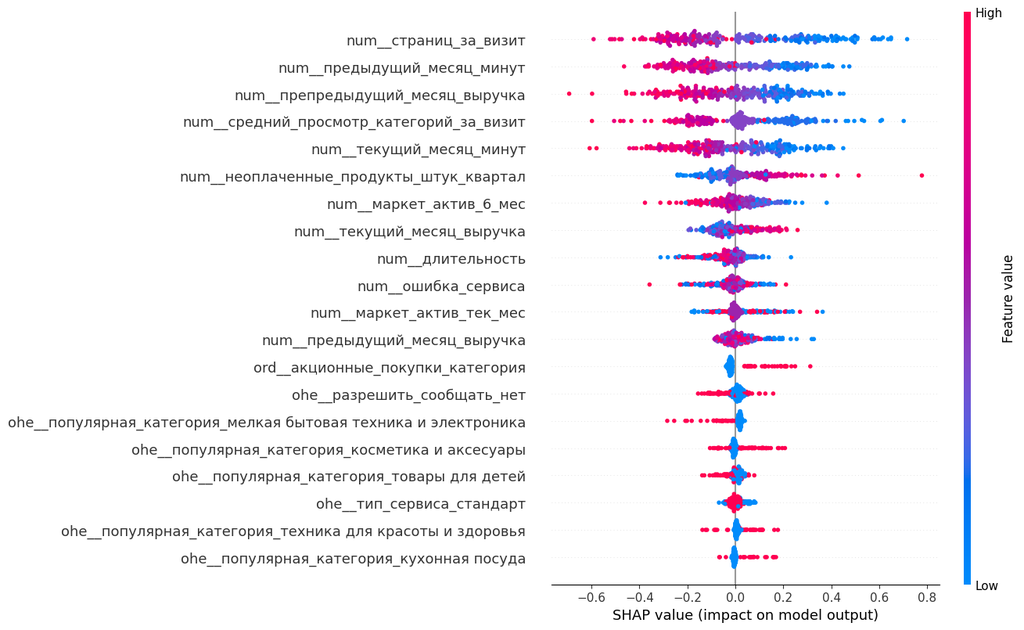

```python
shap.plots.beeswarm(shap_values, max_display=22)
```

Существенно уменьшают вероятность снижения активости пользователя следующие факторы:

- Среднее количество страниц, которые просмотрел покупатель за один визит на сайт за последние 3 месяца.
- Количество минут, проведённых на сайте в текущем и предыдущем месяце.
- Средний просмотр категорий за визит в течение последнего месяца.
- Выручка за предпредыдущий месяц (т.е. снижение выручки в текущем месяце вероятно приведет к снижение покупательской активности через 2 месяца).
- Среднемесячное значение маркетинговых коммуникаций компании, которое приходилось на покупателя за последние 6 месяцев.

Следовательно, чтобы удержать активных пользователей, необходимо в первую очередь ориентироваться на эти признаки, когда будем искать наш целевой сегмент.

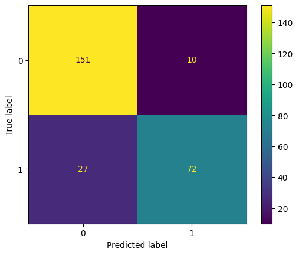

```python
# Посмотрим подробней на confusion matrix и на значения, в которых модель делала ошибочные предсказания
plot_confusion_matrix(best_model, X_test, y_test)
```

```python
# Подтянем в X_test предсказанные и фактические значения целевого признака
X_test_full = pd.DataFrame(X_test)

y_test_proba = best_model.predict_proba(X_test)[:,1]
y_test_pred = best_model.predict(X_test)

X_test_full['вероятность_снижения_покупательской_активности'] = y_test_proba
X_test_full['предсказанная_покупательская_активность'] = y_test_pred
X_test_full['реальная_покупательская_активность'] = y_test

X_test_full = X_test_full.reset_index()
```

```python
X_test_full.head()
```

|  | id | тип_сервиса | разрешить_сообщать | маркет_актив_6_мес | маркет_актив_тек_мес | длительность | популярная_категория | средний_просмотр_категорий_за_визит | неоплаченные_продукты_штук_квартал | ошибка_сервиса | страниц_за_визит | предыдущий_месяц_выручка | препредыдущий_месяц_выручка | текущий_месяц_выручка | предыдущий_месяц_минут | текущий_месяц_минут | акционные_покупки_категория | вероятность_снижения_покупательской_активности | предсказанная_покупательская_активность | реальная_покупательская_активность |
| --- | --- | --- | --- | --- | --- | --- | --- | --- | --- | --- | --- | --- | --- | --- | --- | --- | --- | --- | --- | --- |
| 0 | 215746 | премиум | да | 4.4 | 4 | 987 | техника для красоты и здоровья | 3 | 1 | 8 | 6 | 3222.0 | 4932.0 | 4169.7 | 10 | 9 | без_акций | 0.506941 | 0 | 1 |
| 1 | 215616 | стандарт | нет | 4.0 | 5 | 862 | товары для детей | 2 | 7 | 6 | 5 | 5604.0 | 4308.0 | 6055.1 | 10 | 8 | без_акций | 0.980116 | 1 | 1 |
| 2 | 215951 | стандарт | да | 5.5 | 3 | 473 | домашний текстиль | 6 | 1 | 3 | 10 | 4721.0 | 4667.0 | 4897.8 | 13 | 18 | без_акций | 0.082443 | 0 | 0 |
| 3 | 216224 | стандарт | да | 4.3 | 5 | 446 | мелкая бытовая техника и электроника | 4 | 1 | 5 | 5 | 4329.0 | 4683.0 | 4152.2 | 19 | 14 | без_акций | 0.017617 | 0 | 0 |
| 4 | 216235 | премиум | нет | 4.2 | 4 | 978 | кухонная посуда | 2 | 0 | 2 | 5 | 4480.0 | 5176.0 | 4006.8 | 18 | 15 | без_акций | 0.106334 | 0 | 0 |

Посмотрим на отдельные примеры неверно классифицированных объектов. Для этого отфильтруем такие наблюдения по двум критериям:

- Истинное значение целевого признака — 1 (активность снизилась)
- Вероятность принадлежность к классу 1 была оценена ниже чем 0.3 (модель предсказала, что активность не изменится)

```python
X_test_full[(X_test_full['реальная_покупательская_активность']==1)&(X_test_full['вероятность_снижения_покупательской_активности']<0.3)].sort_values(by='вероятность_снижения_покупательской_активности')
```

|  | id | тип_сервиса | разрешить_сообщать | маркет_актив_6_мес | маркет_актив_тек_мес | длительность | популярная_категория | средний_просмотр_категорий_за_визит | неоплаченные_продукты_штук_квартал | ошибка_сервиса | страниц_за_визит | предыдущий_месяц_выручка | препредыдущий_месяц_выручка | текущий_месяц_выручка | предыдущий_месяц_минут | текущий_месяц_минут | акционные_покупки_категория | вероятность_снижения_покупательской_активности | предсказанная_покупательская_активность | реальная_покупательская_активность |
| --- | --- | --- | --- | --- | --- | --- | --- | --- | --- | --- | --- | --- | --- | --- | --- | --- | --- | --- | --- | --- |
| 251 | 215825 | премиум | да | 4.3 | 4 | 951 | домашний текстиль | 3 | 3 | 4 | 10 | 5063.5 | 5053.0 | 5202.6 | 17 | 15 | без_акций | 0.000754 | 0 | 1 |
| 68 | 215802 | стандарт | да | 3.4 | 4 | 698 | кухонная посуда | 4 | 3 | 4 | 11 | 4955.0 | 5154.0 | 5257.9 | 11 | 20 | без_акций | 0.024487 | 0 | 1 |
| 201 | 215677 | премиум | да | 4.6 | 4 | 993 | домашний текстиль | 2 | 3 | 9 | 11 | 4829.0 | 4538.0 | 5211.2 | 17 | 16 | без_акций | 0.059209 | 0 | 1 |
| 234 | 215913 | стандарт | нет | 4.0 | 4 | 243 | косметика и аксесуары | 2 | 2 | 6 | 13 | 4640.0 | 4995.0 | 5078.1 | 16 | 12 | без_акций | 0.077451 | 0 | 1 |
| 164 | 215907 | стандарт | да | 6.6 | 3 | 839 | косметика и аксесуары | 3 | 3 | 4 | 15 | 4830.0 | 4779.0 | 4915.8 | 14 | 11 | без_акций | 0.093600 | 0 | 1 |
| 121 | 215925 | стандарт | нет | 4.9 | 4 | 450 | мелкая бытовая техника и электроника | 2 | 2 | 4 | 13 | 4458.0 | 5028.0 | 4094.0 | 23 | 12 | без_акций | 0.098287 | 0 | 1 |
| 134 | 215824 | стандарт | нет | 3.9 | 5 | 852 | косметика и аксесуары | 3 | 0 | 2 | 7 | 4950.5 | 4781.0 | 5227.4 | 15 | 12 | без_акций | 0.112994 | 0 | 1 |
| 77 | 215806 | стандарт | нет | 5.8 | 3 | 660 | товары для детей | 4 | 1 | 3 | 12 | 4787.5 | 4507.0 | 5160.6 | 16 | 7 | без_акций | 0.125937 | 0 | 1 |
| 53 | 215810 | стандарт | нет | 4.4 | 4 | 417 | товары для детей | 3 | 0 | 6 | 10 | 5515.0 | 4663.0 | 6383.4 | 16 | 10 | без_акций | 0.129856 | 0 | 1 |
| 165 | 215939 | стандарт | да | 2.6 | 3 | 966 | товары для детей | 3 | 1 | 6 | 9 | 4709.5 | 5509.0 | 4146.6 | 15 | 22 | без_акций | 0.145988 | 0 | 1 |
| 146 | 215921 | стандарт | нет | 3.6 | 3 | 744 | товары для детей | 2 | 1 | 4 | 15 | 4618.5 | 5208.0 | 4237.6 | 20 | 12 | без_акций | 0.220429 | 0 | 1 |
| 78 | 215938 | стандарт | да | 5.2 | 3 | 591 | техника для красоты и здоровья | 2 | 1 | 4 | 17 | 5922.5 | 4439.0 | 7338.2 | 15 | 13 | без_акций | 0.273824 | 0 | 1 |
| 20 | 215458 | стандарт | да | 4.4 | 3 | 851 | косметика и аксесуары | 3 | 3 | 4 | 6 | 5772.5 | 4925.0 | 6187.2 | 14 | 15 | без_акций | 0.297664 | 0 | 1 |

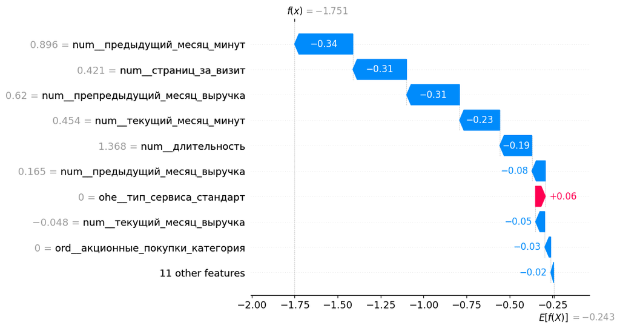

```python
shap.plots.waterfall(shap_values[251])
```

Поведение на сайте и продуктовое поведение данного пользователя достаточно хорошие (много времени проводит на сайте, выручка в последние месяцы выросла и т.д.), поэтому модель не предсказала снижение его активности, хотя фактически это произошло.

Также посмотрим случай, когда модель ошиблась, предсказав снижение активности, а его не произошло:

```python
X_test_full[(X_test_full['реальная_покупательская_активность']==0)&(X_test_full['вероятность_снижения_покупательской_активности']>0.7)].sort_values(by='вероятность_снижения_покупательской_активности', ascending=False)
```

|  | id | тип_сервиса | разрешить_сообщать | маркет_актив_6_мес | маркет_актив_тек_мес | длительность | популярная_категория | средний_просмотр_категорий_за_визит | неоплаченные_продукты_штук_квартал | ошибка_сервиса | страниц_за_визит | предыдущий_месяц_выручка | препредыдущий_месяц_выручка | текущий_месяц_выручка | предыдущий_месяц_минут | текущий_месяц_минут | акционные_покупки_категория | вероятность_снижения_покупательской_активности | предсказанная_покупательская_активность | реальная_покупательская_активность |
| --- | --- | --- | --- | --- | --- | --- | --- | --- | --- | --- | --- | --- | --- | --- | --- | --- | --- | --- | --- | --- |
| 103 | 216636 | премиум | да | 2.4 | 4 | 996 | кухонная посуда | 3 | 4 | 5 | 6 | 5644.5 | 4860.0 | 6454.4 | 10 | 14 | без_акций | 0.945345 | 1 | 0 |
| 16 | 216115 | стандарт | нет | 4.4 | 4 | 808 | мелкая бытовая техника и электроника | 4 | 2 | 0 | 3 | 4802.5 | 4543.0 | 5157.4 | 11 | 9 | без_акций | 0.806865 | 1 | 0 |
| 194 | 215764 | стандарт | да | 4.0 | 4 | 539 | косметика и аксесуары | 2 | 2 | 5 | 7 | 5878.5 | 4359.0 | 7325.4 | 15 | 5 | без_акций | 0.701301 | 1 | 0 |

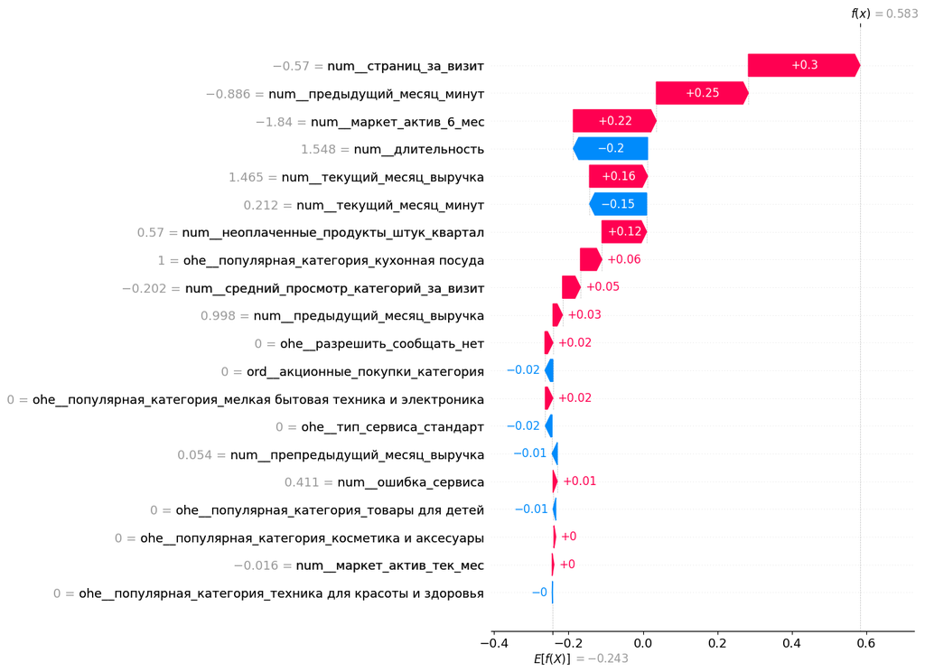

```python
shap.plots.waterfall(shap_values[103], max_display=22)
```

### Permutation importance

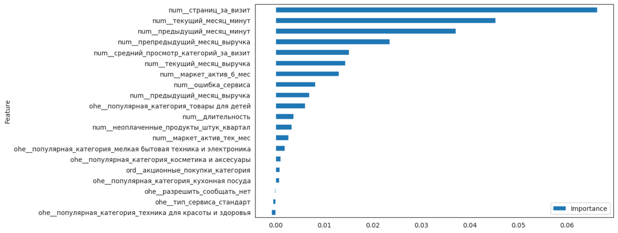

```python
# Оценка важности признаков
result = permutation_importance(best_model.named_steps['models'], X_test_processed, y_test, scoring='roc_auc', random_state=RANDOM_STATE)



feature_importance = pd.DataFrame({'Feature': X_test_processed.columns, 'Importance': result['importances_mean']})
feature_importance = feature_importance.sort_values('Importance', ascending=True)
sns.set_style('white')
feature_importance.plot(x='Feature', y='Importance', kind='barh', figsize=(10, 6))
plt.show()
```

Проверим важность признаков после их перестановки.

**Адекватность уровня обучения:** Сохранение значимости признаков может свидетельствовать о том, что модель адекватно обучилась на тренировочной выборке.

### Выводы

**Важные факторы для удержания пользователей**

- Среднее количество страниц, просмотренных за визит.
- Время, проведенное на сайте в текущем и предыдущем месяце.
- Средний просмотр категорий за визит.
- Выручка за предпредыдущий месяц.
- Среднемесячное значение маркетинговых коммуникаций.

## Сегментация покупателей

Выделим нужный нам сегмент покупателей, проанализируем его и предложим, как увеличить его покупательскую активность. Используем данные моделирования, данные о прибыли покупателей и исходные данные (если понадобятся).

Ниже несколько примеров сегментов, перечисленные в задании:

- Группа клиентов с максимальной долей покупок по акции и высокой вероятностью снижения покупательской активности.
- Группа клиентов, которые покупают только технику, то есть товары с длинным жизненным циклом.
- Группа клиентов, которые покупают товары из категории «Товары для себя» (новая категория, которую можно выделить на основе текущих) или «Товары для детей».
- Группа клиентов с высокой вероятностью снижения покупательской активности и наиболее высокой прибыльностью.

Одной из задач исследования является поиск сегмента постоянных клиентов, чтобы по возможности удерживать активность с помощью персонализированной рекламы. Попробуем найти такой сегмент.

### Сегменты покупателей

Добавим к исходной таблице информацию о прибыли, полученной с каждого клиента.

```python
print(market.shape)
print(money.shape)
```

```
(1296, 17)
(1299, 2)
```

```python
market.head()
```

| id | покупательская_активность | тип_сервиса | разрешить_сообщать | маркет_актив_6_мес | маркет_актив_тек_мес | длительность | популярная_категория | средний_просмотр_категорий_за_визит | неоплаченные_продукты_штук_квартал | ошибка_сервиса | страниц_за_визит | предыдущий_месяц_выручка | препредыдущий_месяц_выручка | текущий_месяц_выручка | предыдущий_месяц_минут | текущий_месяц_минут | акционные_покупки_категория |
| --- | --- | --- | --- | --- | --- | --- | --- | --- | --- | --- | --- | --- | --- | --- | --- | --- | --- |
| 215349 | снизилась | премиум | да | 4.4 | 4 | 819 | товары для детей | 4 | 4 | 2 | 5 | 5216.0 | 4472.0 | 4971.6 | 12 | 10 | по_акциям |
| 215350 | снизилась | стандарт | нет | 4.9 | 3 | 539 | домашний текстиль | 5 | 2 | 1 | 5 | 5457.5 | 4826.0 | 5058.4 | 8 | 13 | без_акций |
| 215351 | снизилась | стандарт | да | 3.2 | 5 | 896 | товары для детей | 5 | 0 | 6 | 4 | 6158.0 | 4793.0 | 6610.4 | 11 | 13 | по_акциям |
| 215352 | снизилась | стандарт | нет | 5.1 | 3 | 1064 | товары для детей | 3 | 2 | 3 | 2 | 5807.5 | 4594.0 | 5872.5 | 8 | 11 | по_акциям |
| 215353 | снизилась | стандарт | да | 3.3 | 4 | 762 | домашний текстиль | 4 | 1 | 1 | 4 | 4738.5 | 5124.0 | 5388.5 | 10 | 10 | без_акций |

```python
money.head()
```

|  | id | прибыль |
| --- | --- | --- |
| 0 | 215348 | 0.98 |
| 1 | 215349 | 4.16 |
| 2 | 215350 | 3.13 |
| 3 | 215351 | 4.87 |
| 4 | 215352 | 4.21 |

```python
money = money.set_index('id')
```

```python
money.head()
```

| id | прибыль |
| --- | --- |
| 215348 | 0.98 |
| 215349 | 4.16 |
| 215350 | 3.13 |
| 215351 | 4.87 |
| 215352 | 4.21 |

```python
market_full = market.merge(money, how='left', left_index=True, right_index=True)
```

```python
market_full.head()
```

| id | покупательская_активность | тип_сервиса | разрешить_сообщать | маркет_актив_6_мес | маркет_актив_тек_мес | длительность | популярная_категория | средний_просмотр_категорий_за_визит | неоплаченные_продукты_штук_квартал | ошибка_сервиса | страниц_за_визит | предыдущий_месяц_выручка | препредыдущий_месяц_выручка | текущий_месяц_выручка | предыдущий_месяц_минут | текущий_месяц_минут | акционные_покупки_категория | прибыль |
| --- | --- | --- | --- | --- | --- | --- | --- | --- | --- | --- | --- | --- | --- | --- | --- | --- | --- | --- |
| 215349 | снизилась | премиум | да | 4.4 | 4 | 819 | товары для детей | 4 | 4 | 2 | 5 | 5216.0 | 4472.0 | 4971.6 | 12 | 10 | по_акциям | 4.16 |
| 215350 | снизилась | стандарт | нет | 4.9 | 3 | 539 | домашний текстиль | 5 | 2 | 1 | 5 | 5457.5 | 4826.0 | 5058.4 | 8 | 13 | без_акций | 3.13 |
| 215351 | снизилась | стандарт | да | 3.2 | 5 | 896 | товары для детей | 5 | 0 | 6 | 4 | 6158.0 | 4793.0 | 6610.4 | 11 | 13 | по_акциям | 4.87 |
| 215352 | снизилась | стандарт | нет | 5.1 | 3 | 1064 | товары для детей | 3 | 2 | 3 | 2 | 5807.5 | 4594.0 | 5872.5 | 8 | 11 | по_акциям | 4.21 |
| 215353 | снизилась | стандарт | да | 3.3 | 4 | 762 | домашний текстиль | 4 | 1 | 1 | 4 | 4738.5 | 5124.0 | 5388.5 | 10 | 10 | без_акций | 3.95 |

```python
market_full.shape
```

```
(1296, 18)
```

```python
market_full.isna().sum()
```

|  | 0 |
| --- | --- |
| покупательская_активность | 0 |
| тип_сервиса | 0 |
| разрешить_сообщать | 0 |
| маркет_актив_6_мес | 0 |
| маркет_актив_тек_мес | 0 |
| длительность | 0 |
| популярная_категория | 0 |
| средний_просмотр_категорий_за_визит | 0 |
| неоплаченные_продукты_штук_квартал | 0 |
| ошибка_сервиса | 0 |
| страниц_за_визит | 0 |
| предыдущий_месяц_выручка | 0 |
| препредыдущий_месяц_выручка | 0 |
| текущий_месяц_выручка | 0 |
| предыдущий_месяц_минут | 0 |
| текущий_месяц_минут | 0 |
| акционные_покупки_категория | 0 |
| прибыль | 0 |

**dtype:** int64

Данные успешно подтянулись.

Отдельно также подтянем данные о прибыли в тестовую выборку.

```python
X_test_full = X_test_full.merge(money, how='left', left_on='id', right_index=True)
```

```python
X_test_full.head()
```

|  | id | тип_сервиса | разрешить_сообщать | маркет_актив_6_мес | маркет_актив_тек_мес | длительность | популярная_категория | средний_просмотр_категорий_за_визит | неоплаченные_продукты_штук_квартал | ошибка_сервиса | ... | предыдущий_месяц_выручка | препредыдущий_месяц_выручка | текущий_месяц_выручка | предыдущий_месяц_минут | текущий_месяц_минут | акционные_покупки_категория | вероятность_снижения_покупательской_активности | предсказанная_покупательская_активность | реальная_покупательская_активность | прибыль |
| --- | --- | --- | --- | --- | --- | --- | --- | --- | --- | --- | --- | --- | --- | --- | --- | --- | --- | --- | --- | --- | --- |
| 0 | 215746 | премиум | да | 4.4 | 4 | 987 | техника для красоты и здоровья | 3 | 1 | 8 | ... | 3222.0 | 4932.0 | 4169.7 | 10 | 9 | без_акций | 0.506941 | 0 | 1 | 3.26 |
| 1 | 215616 | стандарт | нет | 4.0 | 5 | 862 | товары для детей | 2 | 7 | 6 | ... | 5604.0 | 4308.0 | 6055.1 | 10 | 8 | без_акций | 0.980116 | 1 | 1 | 3.49 |
| 2 | 215951 | стандарт | да | 5.5 | 3 | 473 | домашний текстиль | 6 | 1 | 3 | ... | 4721.0 | 4667.0 | 4897.8 | 13 | 18 | без_акций | 0.082443 | 0 | 0 | 4.29 |
| 3 | 216224 | стандарт | да | 4.3 | 5 | 446 | мелкая бытовая техника и электроника | 4 | 1 | 5 | ... | 4329.0 | 4683.0 | 4152.2 | 19 | 14 | без_акций | 0.017617 | 0 | 0 | 3.99 |
| 4 | 216235 | премиум | нет | 4.2 | 4 | 978 | кухонная посуда | 2 | 0 | 2 | ... | 4480.0 | 5176.0 | 4006.8 | 18 | 15 | без_акций | 0.106334 | 0 | 0 | 4.37 |

5 rows × 21 columns

```python
X_test_full.shape
```

```
(260, 21)
```

Для начала произведем сегментацию клиентов по категориям, указанным в задании:

- Группа клиентов с максимальной долей покупок по акции и высокой вероятностью снижения покупательской активности.
- Группа клиентов, которые покупают только технику, то есть товары с длинным жизненным циклом.
- Группа клиентов, которые покупают товары из категории «Товары для себя» (новая категория, которую можно выделить на основе текущих) или «Товары для детей».
- Группа клиентов с высокой вероятностью снижения покупательской активности и наиболее высокой прибыльностью.

#### Сегментация 1: Группа клиентов с максимальной долей покупок по акции и высокой вероятностью снижения покупательской активности.

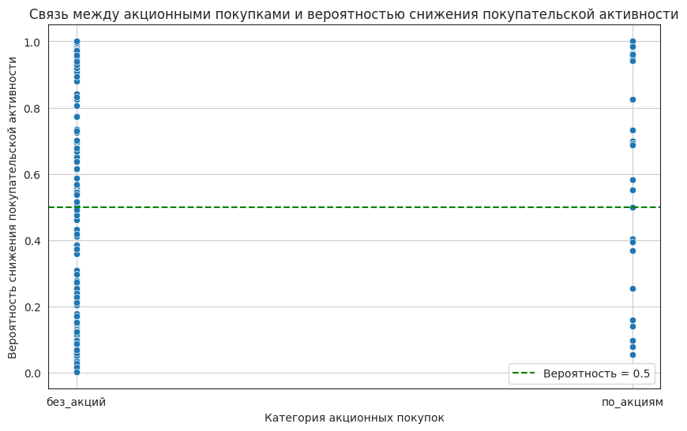

```python
plt.figure(figsize=(10, 6))
sns.scatterplot(data=X_test_full, x='акционные_покупки_категория', y='вероятность_снижения_покупательской_активности')
plt.title('Связь между акционными покупками и вероятностью снижения покупательской активности')
plt.xlabel('Категория акционных покупок')
plt.ylabel('Вероятность снижения покупательской активности')

# Добавляем горизонтальную линию
plt.axhline(y=0.5, color='green', linestyle='--', label='Вероятность = 0.5')

plt.grid(True)
plt.legend()
plt.show()
```

**Сегментация 1:**

|  | Высокая вероятность снижения активности | Низкая вероятность снижения активности |
| --- | --- | --- |
| **Высокая доля покупок по акциям** | Группа 1 | Группа 3 |
| **Низкая доля покупок по акциям** | Группа 2 | Группа 4 |

**Группа 1:** Высокая вероятность снижения активности и высокая доля покупок по акциям Эта группа характеризуется потребителями, которые активно участвуют в акциях и скидках, но, несмотря на это, существует высокая вероятность снижения их покупательской активности. Возможно, они реагируют на временные предложения, но в долгосрочной перспективе могут потерять интерес к бренду или продукту.

**Группа 4:** Низкая вероятность снижения активности и низкая доля покупок по акциям Потребители этой группы не участвуют в акциях и имеют низкую активность. Они могут быть менее заинтересованы в продукте или бренде, что делает их менее предсказуемыми и потенциально трудными для привлечения.

Нас интересует группа клиентов с максимальной долей покупок по акции и высокой вероятностью снижения покупательской активности, т.е. Группа 1. Произведем сегментацию и посмотрим средние финансовые показатели каждой группы.

```python
def segnmentation_1(row):
    """
    Определяет группу сегментации на основе вероятности снижения покупательской активности
    и категории акционных покупок.

    Параметры:
    row: объект Series (например, строка DataFrame), содержащий данные о клиенте,
         включая вероятность снижения покупательской активности и категорию акционных покупок.

    Возвращает:
    str: Название группы ('Группа 1', 'Группа 2', 'Группа 3' или 'Группа 4').
    """

    # Проверяем, превышает ли вероятность снижения покупательской активности 0.5
    if row['вероятность_снижения_покупательской_активности'] >= 0.5:
        # Если вероятность высокая и покупка по акциям
        if row['акционные_покупки_категория'] == 'по_акциям':
            return 'Группа 1'  # Группа для клиентов с высокой вероятностью снижения активности
        else:
            return 'Группа 2'  # Группа для клиентов с высокой вероятностью, но без акционных покупок
    else:
        # Если вероятность ниже 0.5 и покупка по акциям
        if row['акционные_покупки_категория'] == 'по_акциям':
            return 'Группа 3'  # Группа для клиентов с низкой вероятностью снижения активности, но с акциями
        else:
            return 'Группа 4'  # Группа для клиентов с низкой вероятностью и без акционных покупок
```

```python
X_test_full['сегментация_1'] = X_test_full.apply(segnmentation_1, axis=1)
```

```python
# СОставим таблицу с финансовой статистикой по каждой группе
segment_1_stats = X_test_full.groupby('сегментация_1')[['препредыдущий_месяц_выручка',
       'предыдущий_месяц_выручка', 'текущий_месяц_выручка', 'прибыль']].mean()
```

```python
# Добавляем долю пользователей в результирующую таблицу
segment_1_stats['доля_пользователей'] = segment_1_stats.index.map(X_test_full['сегментация_1'].value_counts(normalize=True))
```

```python
segment_1_stats
```

| сегментация_1 | препредыдущий_месяц_выручка | предыдущий_месяц_выручка | текущий_месяц_выручка | прибыль | доля_пользователей |
| --- | --- | --- | --- | --- | --- |
| Группа 1 | 4714.120000 | 5062.680000 | 5350.136000 | 3.954800 | 0.096154 |
| Группа 2 | 4605.442857 | 4810.885714 | 5188.851429 | 4.060286 | 0.269231 |
| Группа 3 | 4862.000000 | 5129.666667 | 5616.155556 | 3.187778 | 0.034615 |
| Группа 4 | 4938.826923 | 4886.342949 | 5133.951282 | 4.021859 | 0.600000 |

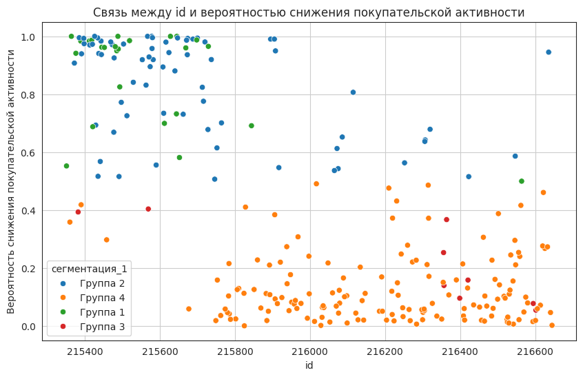

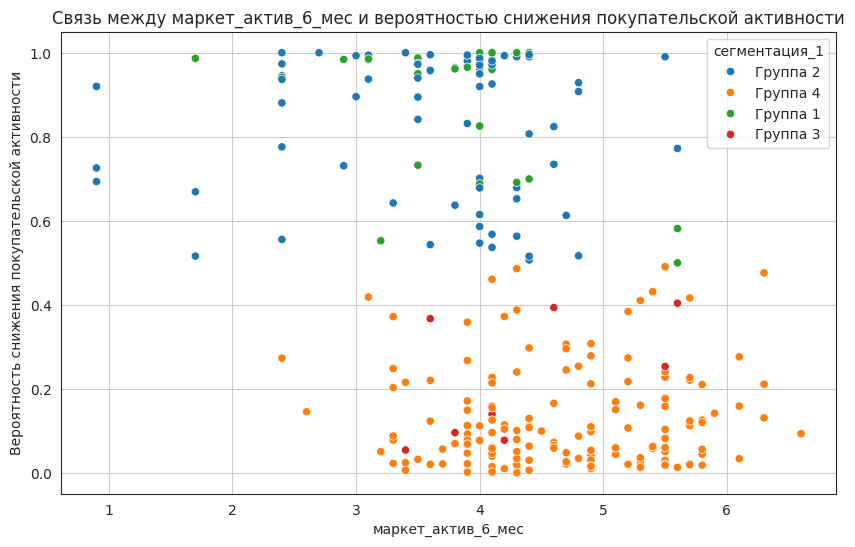

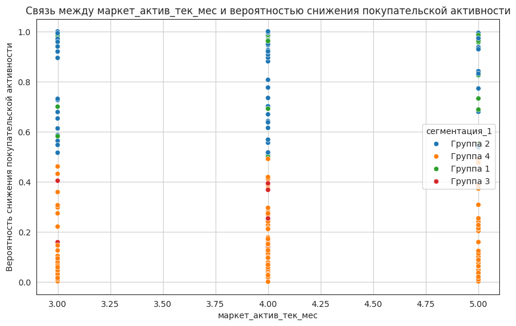

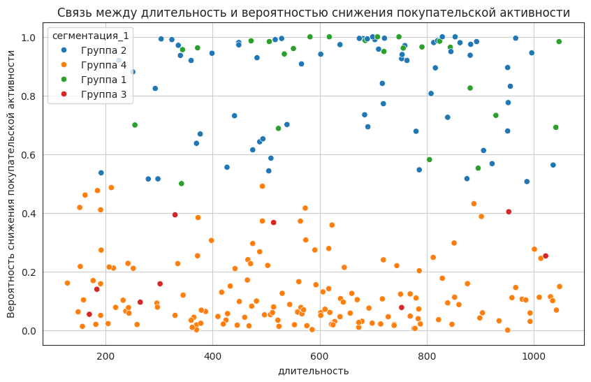

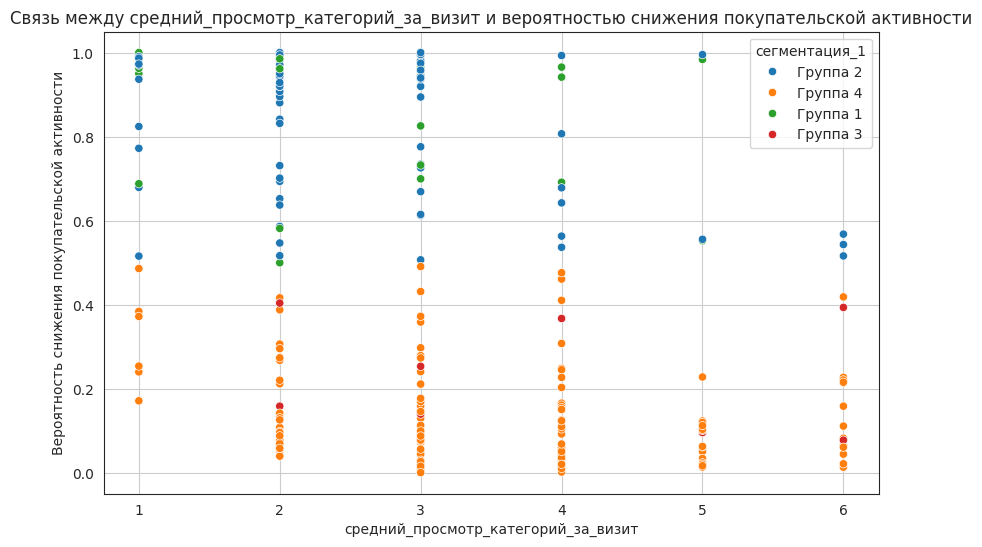

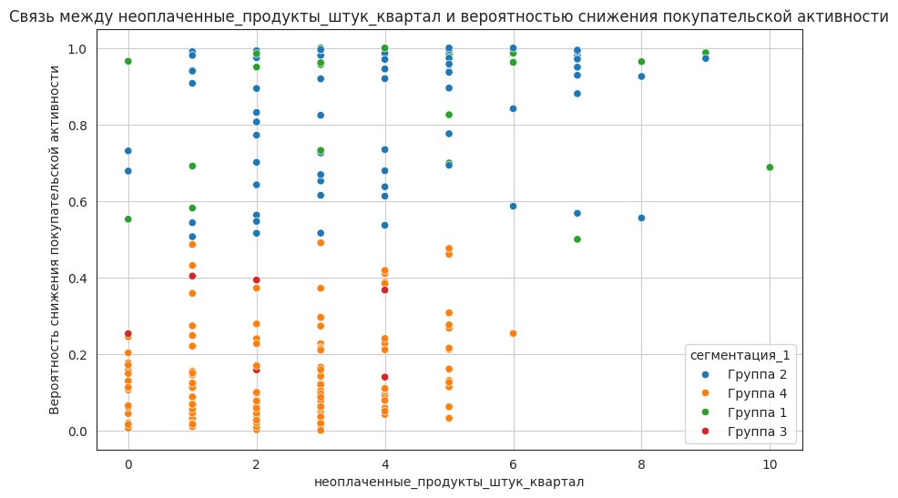

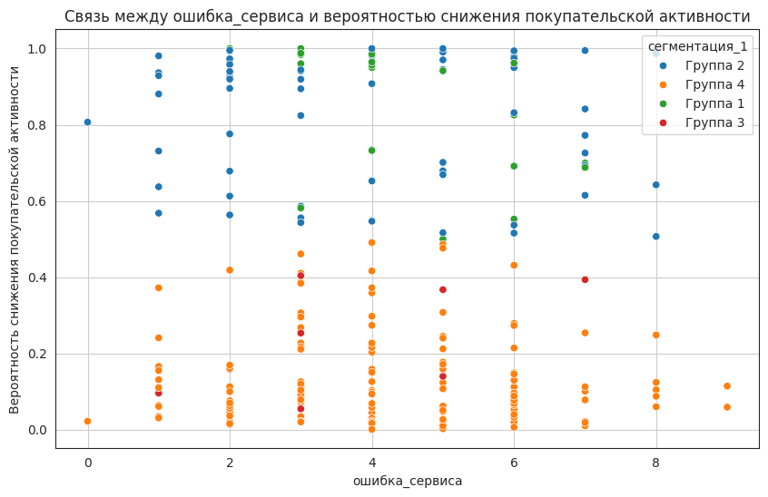

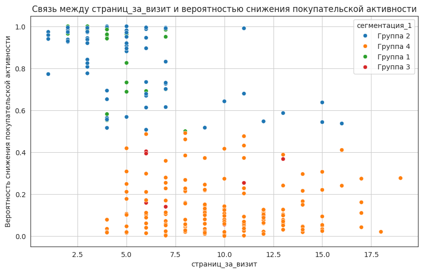

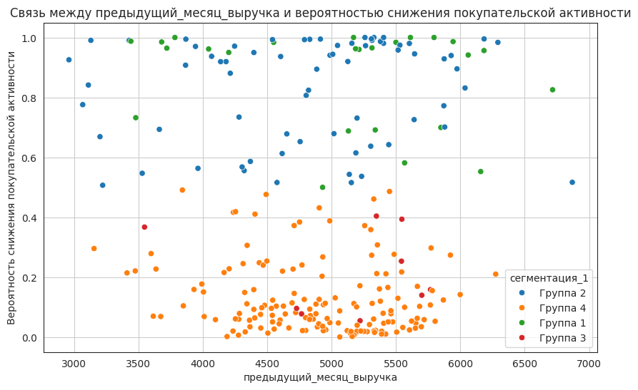

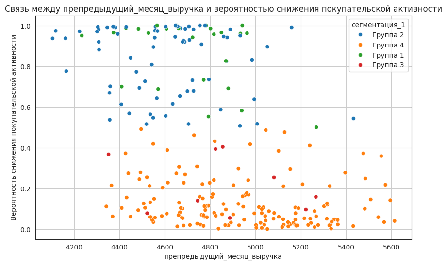

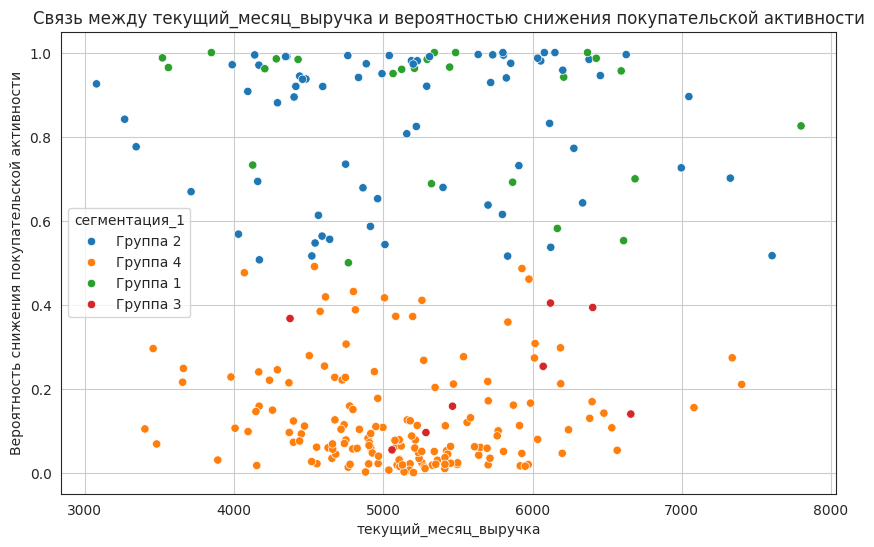

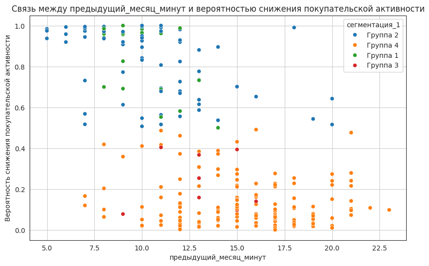

[5 more figures not shown]

```python
for column in X_test_full.select_dtypes(include=['number']).columns:
    plt.figure(figsize=(10, 6))
    sns.scatterplot(data=X_test_full, x=column, y='вероятность_снижения_покупательской_активности', hue='сегментация_1')
    plt.title(f'Связь между {column} и вероятностью снижения покупательской активности')
    plt.xlabel(column)
    plt.ylabel('Вероятность снижения покупательской активности')
    plt.grid(True)
    plt.show()
```

```python
def plot_pie_chart(dataframe, column, title=f'Распределение по категории: {column}'):
    """
    Строит круговую диаграмму по указанной колонке DataFrame.

    :param dataframe: pandas DataFrame
    :param column: строка - название колонки для анализа
    """
    # Подсчитываем количество каждой категории
    category_counts = dataframe[column].value_counts()

    # Настраиваем размер фигуры
    plt.figure(figsize=(10, 7))

    # Строим круговую диаграмму
    plt.pie(category_counts, labels=category_counts.index, autopct='%1.1f%%', startangle=90, colors=plt.cm.Paired(range(len(category_counts))))

    # Добавляем заголовок
    plt.title(title)

    # Обеспечиваем круговую форму
    plt.axis('equal')

    # Показываем график
    plt.show()
```

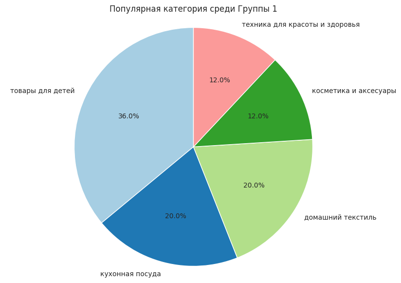

```python
plot_pie_chart(
    X_test_full.query('сегментация_1 == "Группа 1"'),
    'популярная_категория',
    'Популярная категория среди Группы 1')
```

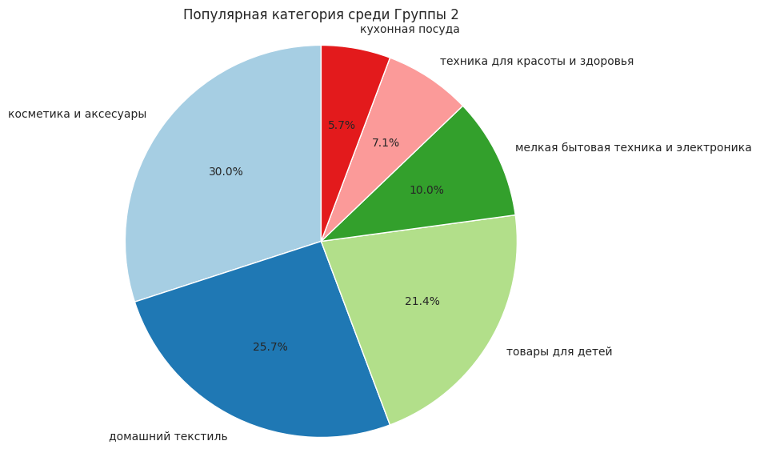

```python
plot_pie_chart(
    X_test_full.query('сегментация_1 == "Группа 2"'),
    'популярная_категория',
    'Популярная категория среди Группы 2')
```

**Группа 1 (повышение лояльности):**

- Несмотря на высокую вероятность снижения активности, демонстрирует рост выручки, что может быть связано с временными акциями. Однако в долгосрочной перспективе необходимо работать над удержанием клиентов.
- Рекомендуется мероприятия, направленные на повышение долгосрочной лояльности. Например, внедрить программу лояльности направленную на данную группу пользователей, предусматривающую систему бонусов за постоянные покупки, что будет стимулировать повторные транзакции.
- Самая популярная категория в этой группе: "Товары для детей" и "Домашний текстиль", следует уделить им особое внимание.

#### Сегментация 2: Группа клиентов, которые покупают только технику, то есть товары с длинным жизненным циклом.

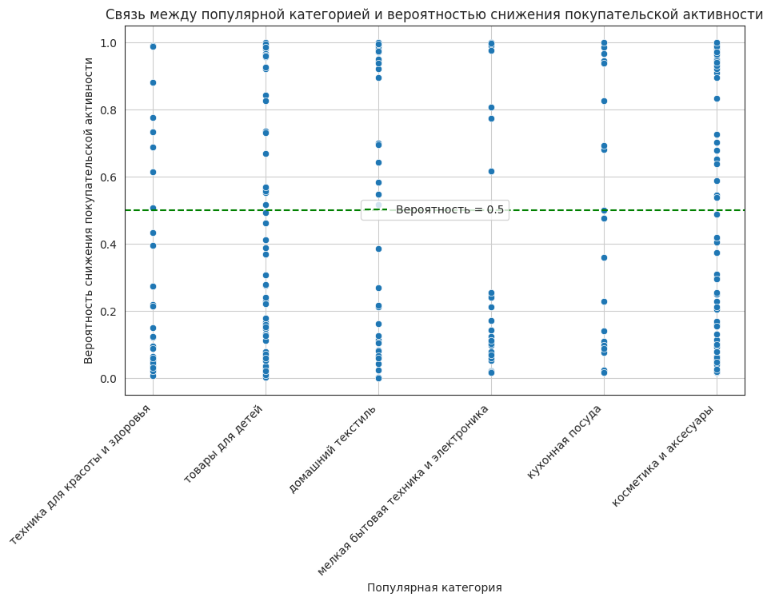

```python
plt.figure(figsize=(10, 6))
sns.scatterplot(data=X_test_full, x='популярная_категория', y='вероятность_снижения_покупательской_активности')
plt.title('Связь между популярной категорией и вероятностью снижения покупательской активности')
plt.xlabel('Популярная категория')
plt.ylabel('Вероятность снижения покупательской активности')

# Добавляем горизонтальную линию
plt.axhline(y=0.5, color='green', linestyle='--', label='Вероятность = 0.5')

# Поворачиваем метки на оси X
plt.xticks(rotation=45, ha='right')

plt.grid(True)
plt.legend()
plt.show()
```

**Сегментация 2:**

|  | Высокая вероятность снижения активности | Низкая вероятность снижения активности |
| --- | --- | --- |
| **Товары с длинным жизненным циклом** | Группа 1 | Группа 3 |
| **Товары с коротким жизненным циклом** | Группа 2 | Группа 4 |

- **Группа 1:** Высокая вероятность снижения активности, товары с длинным жизненным циклом.
- **Группа 2:** Высокая вероятность снижения активности, товары с коротким жизненным циклом.
- **Группа 3:** Низкая вероятность снижения активности, товары с длинным жизненным циклом.
- **Группа 4:** Низкая вероятность снижения активности, товары с коротким жизненным циклом.

Нас интересует Группа 1.

```python
X_test_full.head()
```

|  | id | тип_сервиса | разрешить_сообщать | маркет_актив_6_мес | маркет_актив_тек_мес | длительность | популярная_категория | средний_просмотр_категорий_за_визит | неоплаченные_продукты_штук_квартал | ошибка_сервиса | ... | препредыдущий_месяц_выручка | текущий_месяц_выручка | предыдущий_месяц_минут | текущий_месяц_минут | акционные_покупки_категория | вероятность_снижения_покупательской_активности | предсказанная_покупательская_активность | реальная_покупательская_активность | прибыль | сегментация_1 |
| --- | --- | --- | --- | --- | --- | --- | --- | --- | --- | --- | --- | --- | --- | --- | --- | --- | --- | --- | --- | --- | --- |
| 0 | 215746 | премиум | да | 4.4 | 4 | 987 | техника для красоты и здоровья | 3 | 1 | 8 | ... | 4932.0 | 4169.7 | 10 | 9 | без_акций | 0.506941 | 0 | 1 | 3.26 | Группа 2 |
| 1 | 215616 | стандарт | нет | 4.0 | 5 | 862 | товары для детей | 2 | 7 | 6 | ... | 4308.0 | 6055.1 | 10 | 8 | без_акций | 0.980116 | 1 | 1 | 3.49 | Группа 2 |
| 2 | 215951 | стандарт | да | 5.5 | 3 | 473 | домашний текстиль | 6 | 1 | 3 | ... | 4667.0 | 4897.8 | 13 | 18 | без_акций | 0.082443 | 0 | 0 | 4.29 | Группа 4 |
| 3 | 216224 | стандарт | да | 4.3 | 5 | 446 | мелкая бытовая техника и электроника | 4 | 1 | 5 | ... | 4683.0 | 4152.2 | 19 | 14 | без_акций | 0.017617 | 0 | 0 | 3.99 | Группа 4 |
| 4 | 216235 | премиум | нет | 4.2 | 4 | 978 | кухонная посуда | 2 | 0 | 2 | ... | 5176.0 | 4006.8 | 18 | 15 | без_акций | 0.106334 | 0 | 0 | 4.37 | Группа 4 |

5 rows × 22 columns

```python
def segnmentation_2(row):
    """
    Определяет группу сегментации на основе вероятности снижения покупательской активности
    и популярной категории товара.

    Параметры:
    row: объект Series (например, строка DataFrame), содержащий данные о клиенте,
         включая вероятность снижения покупательской активности и популярную категорию.

    Возвращает:
    str: Название группы ('Группа 1', 'Группа 2', 'Группа 3' или 'Группа 4').
    """

    # Проверяем, превышает ли вероятность снижения покупательской активности 0.5
    if row['вероятность_снижения_покупательской_активности'] >= 0.5:
        # Если вероятность высокая и популярная категория - мелкая бытовая техника и электроника
        if row['популярная_категория'] == 'мелкая бытовая техника и электроника':
            return 'Группа 1'  # Группа для клиентов с высокой вероятностью снижения активности и интересом к данной категории
        else:
            return 'Группа 2'  # Группа для клиентов с высокой вероятностью, но без интереса к данной категории
    else:
        # Если вероятность ниже 0.5 и популярная категория - мелкая бытовая техника и электроника
        if row['популярная_категория'] == 'мелкая бытовая техника и электроника':
            return 'Группа 3'  # Группа для клиентов с низкой вероятностью снижения активности, но с интересом к данной категории
        else:
            return 'Группа 4'  # Группа для клиентов с низкой вероятностью и без интереса к данной категории
```

```python
X_test_full['сегментация_2'] = X_test_full.apply(segnmentation_2, axis=1)
```

```python
# СОставим таблицу с финансовой статистикой по каждой группе
segment_2_stats = X_test_full.groupby('сегментация_2')[['препредыдущий_месяц_выручка',
       'предыдущий_месяц_выручка', 'текущий_месяц_выручка', 'прибыль']].mean()
```

```python
# Добавляем долю пользователей в результирующую таблицу
segment_2_stats['доля_пользователей'] = segment_2_stats.index.map(X_test_full['сегментация_2'].value_counts(normalize=True))
```

```python
segment_2_stats
```

| сегментация_2 | препредыдущий_месяц_выручка | предыдущий_месяц_выручка | текущий_месяц_выручка | прибыль | доля_пользователей |
| --- | --- | --- | --- | --- | --- |
| Группа 1 | 4570.142857 | 5065.571429 | 5554.00000 | 4.010000 | 0.026923 |
| Группа 2 | 4639.125000 | 4862.159091 | 5205.62500 | 4.034318 | 0.338462 |
| Группа 3 | 4905.347826 | 4925.369565 | 5091.93913 | 3.925652 | 0.088462 |
| Группа 4 | 4939.380282 | 4895.443662 | 5171.31831 | 3.984577 | 0.546154 |

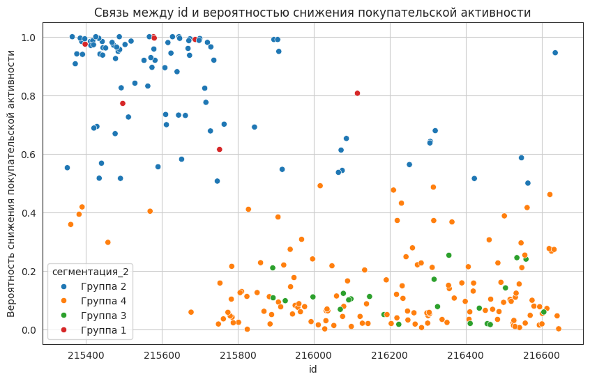

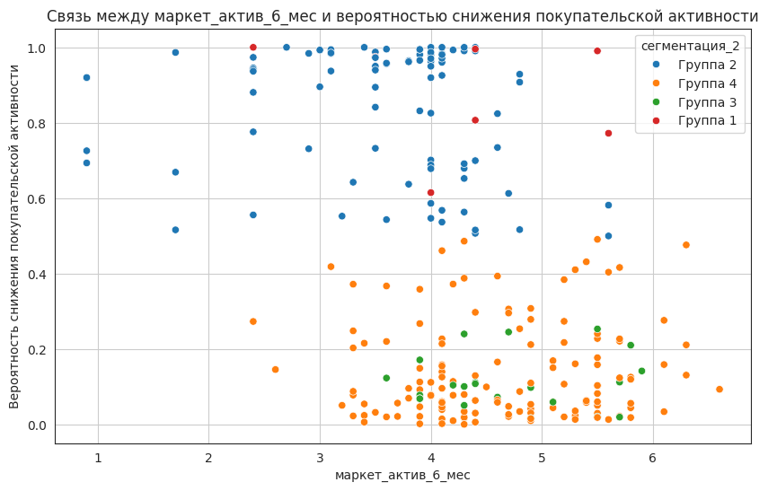

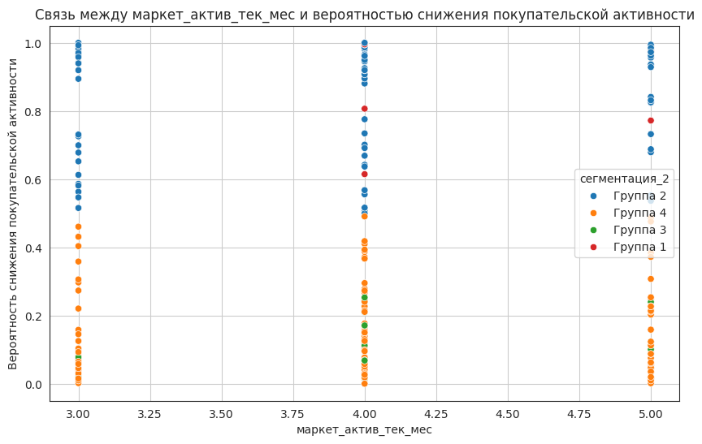

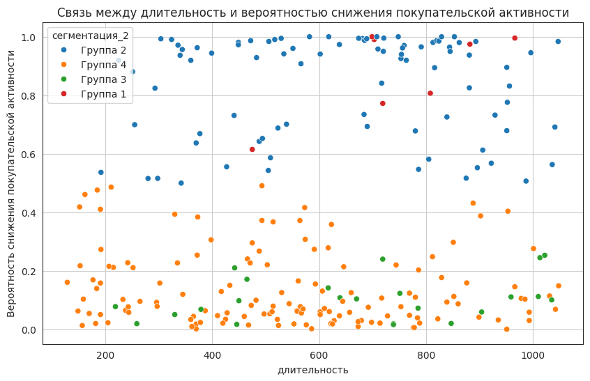

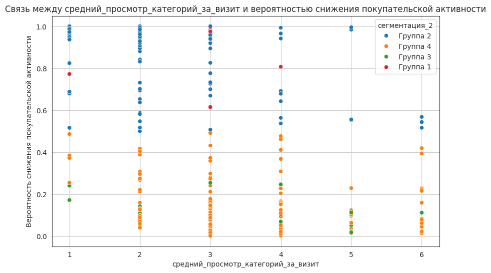

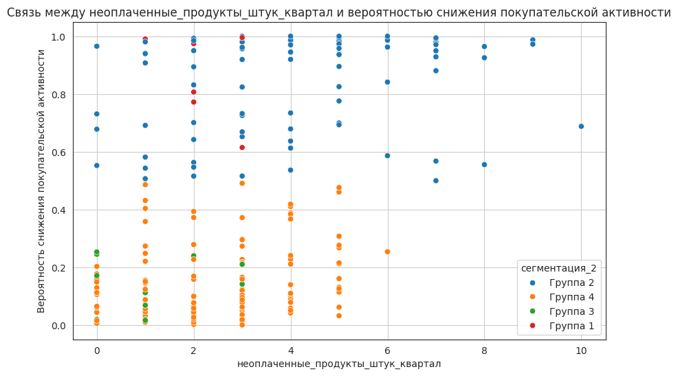

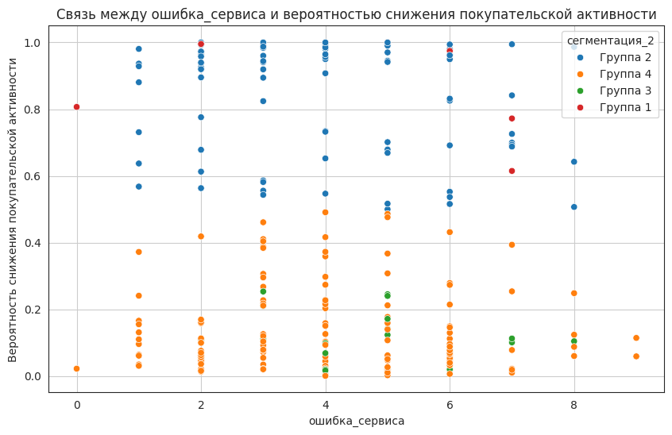

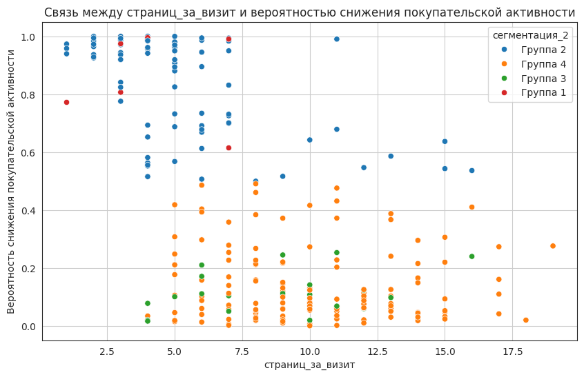

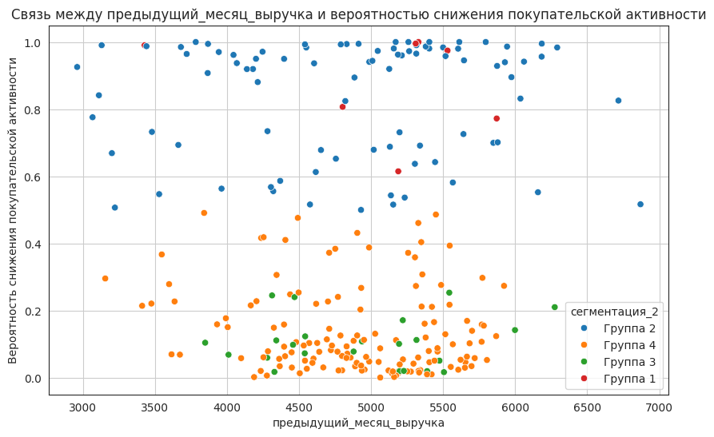

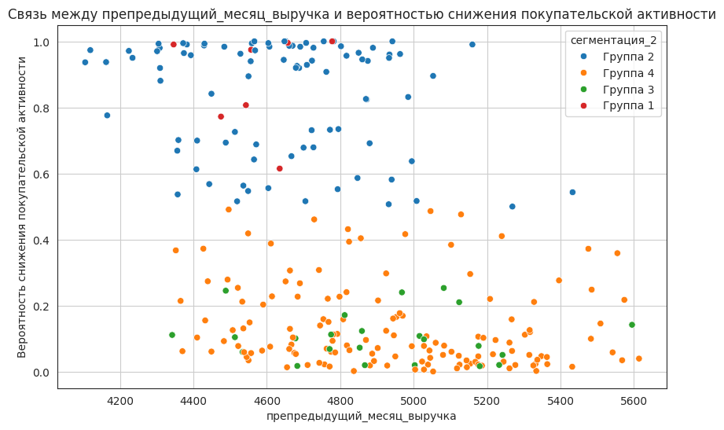

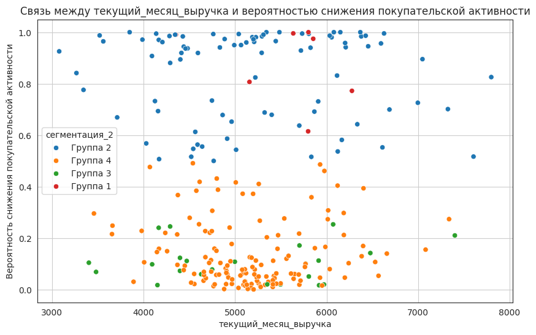

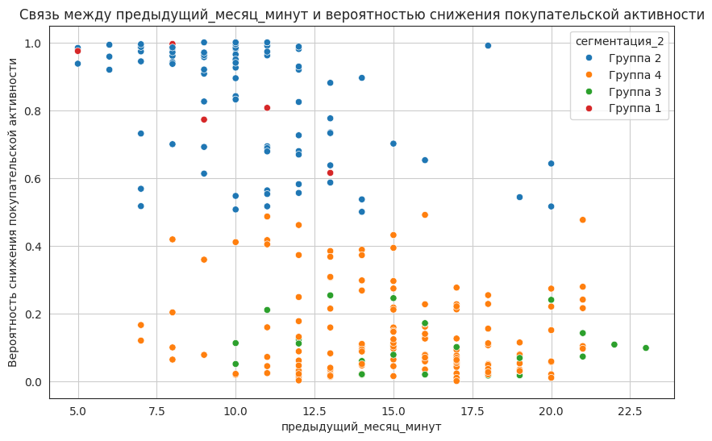

[5 more figures not shown]

```python
for column in X_test_full.select_dtypes(include=['number']).columns:
    plt.figure(figsize=(10, 6))
    sns.scatterplot(data=X_test_full, x=column, y='вероятность_снижения_покупательской_активности', hue='сегментация_2')
    plt.title(f'Связь между {column} и вероятностью снижения покупательской активности')
    plt.xlabel(column)
    plt.ylabel('Вероятность снижения покупательской активности')
    plt.grid(True)
    plt.show()
```

```python
X_test_full
```

|  | id | тип_сервиса | разрешить_сообщать | маркет_актив_6_мес | маркет_актив_тек_мес | длительность | популярная_категория | средний_просмотр_категорий_за_визит | неоплаченные_продукты_штук_квартал | ошибка_сервиса | ... | текущий_месяц_выручка | предыдущий_месяц_минут | текущий_месяц_минут | акционные_покупки_категория | вероятность_снижения_покупательской_активности | предсказанная_покупательская_активность | реальная_покупательская_активность | прибыль | сегментация_1 | сегментация_2 |
| --- | --- | --- | --- | --- | --- | --- | --- | --- | --- | --- | --- | --- | --- | --- | --- | --- | --- | --- | --- | --- | --- |
| 0 | 215746 | премиум | да | 4.4 | 4 | 987 | техника для красоты и здоровья | 3 | 1 | 8 | ... | 4169.7 | 10 | 9 | без_акций | 0.506941 | 0 | 1 | 3.26 | Группа 2 | Группа 2 |
| 1 | 215616 | стандарт | нет | 4.0 | 5 | 862 | товары для детей | 2 | 7 | 6 | ... | 6055.1 | 10 | 8 | без_акций | 0.980116 | 1 | 1 | 3.49 | Группа 2 | Группа 2 |
| 2 | 215951 | стандарт | да | 5.5 | 3 | 473 | домашний текстиль | 6 | 1 | 3 | ... | 4897.8 | 13 | 18 | без_акций | 0.082443 | 0 | 0 | 4.29 | Группа 4 | Группа 4 |
| 3 | 216224 | стандарт | да | 4.3 | 5 | 446 | мелкая бытовая техника и электроника | 4 | 1 | 5 | ... | 4152.2 | 19 | 14 | без_акций | 0.017617 | 0 | 0 | 3.99 | Группа 4 | Группа 3 |
| 4 | 216235 | премиум | нет | 4.2 | 4 | 978 | кухонная посуда | 2 | 0 | 2 | ... | 4006.8 | 18 | 15 | без_акций | 0.106334 | 0 | 0 | 4.37 | Группа 4 | Группа 4 |
| ... | ... | ... | ... | ... | ... | ... | ... | ... | ... | ... | ... | ... | ... | ... | ... | ... | ... | ... | ... | ... | ... |
| 255 | 215391 | премиум | да | 3.5 | 3 | 754 | косметика и аксесуары | 3 | 1 | 2 | ... | 5824.5 | 10 | 11 | без_акций | 0.939764 | 1 | 1 | 5.44 | Группа 2 | Группа 2 |
| 256 | 216065 | стандарт | да | 4.1 | 5 | 192 | косметика и аксесуары | 4 | 4 | 6 | ... | 6122.2 | 14 | 12 | без_акций | 0.536757 | 0 | 0 | 4.46 | Группа 2 | Группа 2 |
| 257 | 216533 | стандарт | нет | 5.7 | 5 | 769 | техника для красоты и здоровья | 4 | 1 | 8 | ... | 5180.3 | 15 | 20 | без_акций | 0.124051 | 0 | 0 | 6.59 | Группа 4 | Группа 4 |
| 258 | 216548 | стандарт | нет | 6.3 | 4 | 252 | косметика и аксесуары | 3 | 4 | 3 | ... | 5470.1 | 15 | 17 | без_акций | 0.211343 | 0 | 0 | 3.78 | Группа 4 | Группа 4 |
| 259 | 216070 | премиум | да | 3.9 | 4 | 379 | мелкая бытовая техника и электроника | 4 | 1 | 4 | ... | 3481.4 | 19 | 21 | без_акций | 0.068784 | 0 | 0 | 3.27 | Группа 4 | Группа 3 |

260 rows × 23 columns

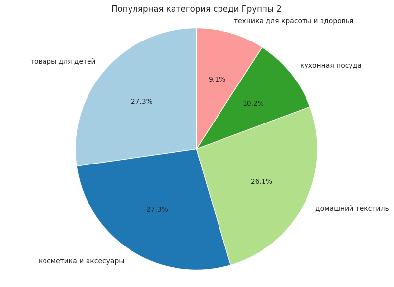

```python
plot_pie_chart(
    X_test_full.query('сегментация_2 == "Группа 2"'),
    'популярная_категория',
    'Популярная категория среди Группы 2')
```

Фокусироваться на удержании данной группы нецелесообразно. Лучше сосредоточиться на Группе 2, которые покупают товары с коротким жизненным циклом, но существует большая вероятность снижения их активности. Самые популярные категории "Товары для детей" и "Косметика и аксесуары".

#### Сегментация 3: Группа клиентов, которые покупают товары из категории «Товары для себя» (новая категория, которую можно выделить на основе текущих) или «Товары для детей».

**Сегментация 3:**

|  | Высокая вероятность снижения активности | Низкая вероятность снижения активности |
| --- | --- | --- |
| **"Товары для себя"** | Группа 1 | Группа 3 |
| **"Товары для детей"** | Группа 2 | Группа 4 |

- **Группа 1:** Высокая вероятность снижения активности, товары для себя.
- **Группа 2:** Высокая вероятность снижения активности, товары для детей.
- **Группа 3:** Низкая вероятность снижения активности, товары для себя.
- **Группа 4:** Низкая вероятность снижения активности, товары для детей.

Нас интересует Группа 1 и Группа 2.

```python
X_test_full['популярная_категория'].unique()
```

```
array(['техника для красоты и здоровья', 'товары для детей',
       'домашний текстиль', 'мелкая бытовая техника и электроника',
       'кухонная посуда', 'косметика и аксесуары'], dtype=object)
```

```python
def segnmentation_3(row):
    """
    Определяет группу сегментации на основе вероятности снижения покупательской активности
    и популярной категории товара.

    Параметры:
    row: объект Series (например, строка DataFrame), содержащий данные о клиенте,
         включая вероятность снижения покупательской активности и популярную категорию.

    Возвращает:
    str: Название группы ('Группа 1', 'Группа 2', 'Группа 3' или 'Группа 4').
    """

    # Проверяем, превышает ли вероятность снижения покупательской активности 0.5
    if row['вероятность_снижения_покупательской_активности'] >= 0.5:
        # Если вероятность высокая и популярная категория не 'товары для детей'
        if row['популярная_категория'] != 'товары для детей':
            return 'Группа 1'  # Группа для клиентов с высокой вероятностью снижения активности и интересом к другим категориям
        else:
            return 'Группа 2'  # Группа для клиентов с высокой вероятностью и интересом к товарам для детей
    else:
        # Если вероятность ниже 0.5 и популярная категория не 'товары для детей'
        if row['популярная_категория'] != 'товары для детей':
            return 'Группа 3'  # Группа для клиентов с низкой вероятностью снижения активности и интересом к другим категориям
        else:
            return 'Группа 4'  # Группа для клиентов с низкой вероятностью и интересом к товарам для детей
```

```python
X_test_full['сегментация_3'] = X_test_full.apply(segnmentation_3, axis=1)
```

```python
# СОставим таблицу с финансовой статистикой по каждой группе
segment_3_stats = X_test_full.groupby('сегментация_3')[['препредыдущий_месяц_выручка',
       'предыдущий_месяц_выручка', 'текущий_месяц_выручка', 'прибыль']].mean()
```

```python
# Добавляем долю пользователей в результирующую таблицу
segment_3_stats['доля_пользователей'] = segment_3_stats.index.map(X_test_full['сегментация_3'].value_counts(normalize=True))
```

```python
segment_3_stats
```

| сегментация_3 | препредыдущий_месяц_выручка | предыдущий_месяц_выручка | текущий_месяц_выручка | прибыль | доля_пользователей |
| --- | --- | --- | --- | --- | --- |
| Группа 1 | 4637.802817 | 5002.387324 | 5367.156338 | 3.984085 | 0.273077 |
| Группа 2 | 4622.916667 | 4506.645833 | 4829.370833 | 4.175833 | 0.092308 |
| Группа 3 | 4936.355932 | 4980.817797 | 5212.867797 | 4.025508 | 0.453846 |
| Группа 4 | 4930.319149 | 4695.744681 | 5028.157447 | 3.852979 | 0.180769 |

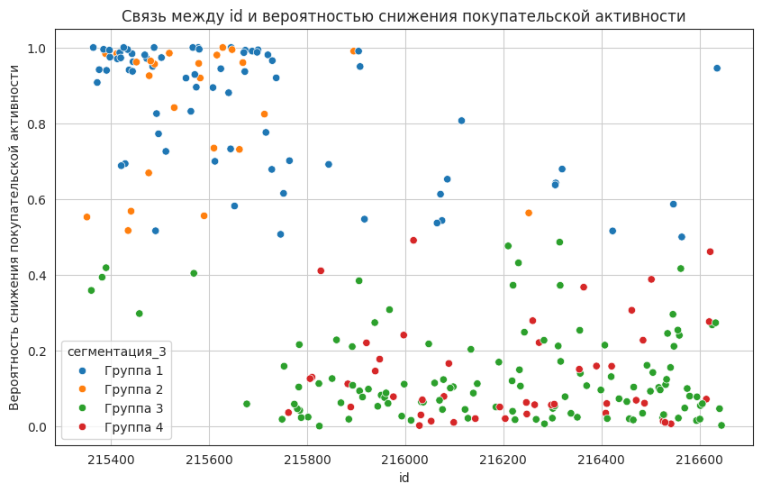

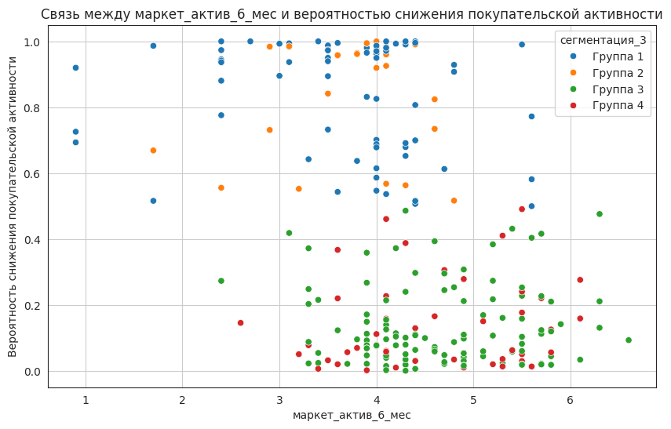

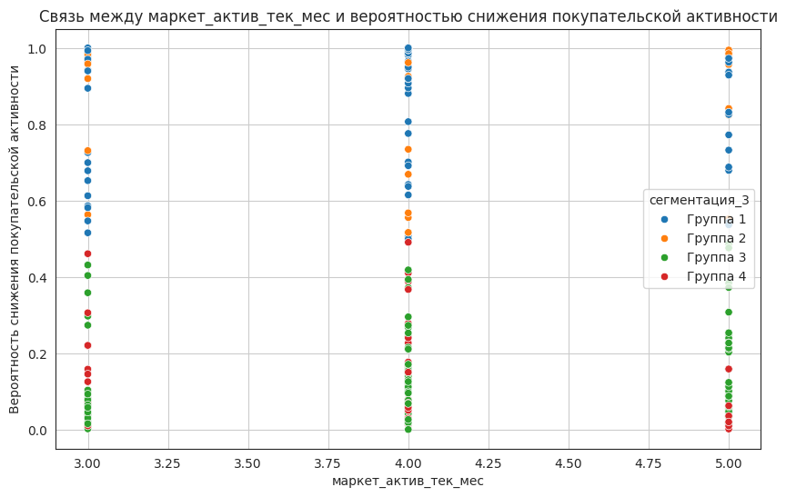

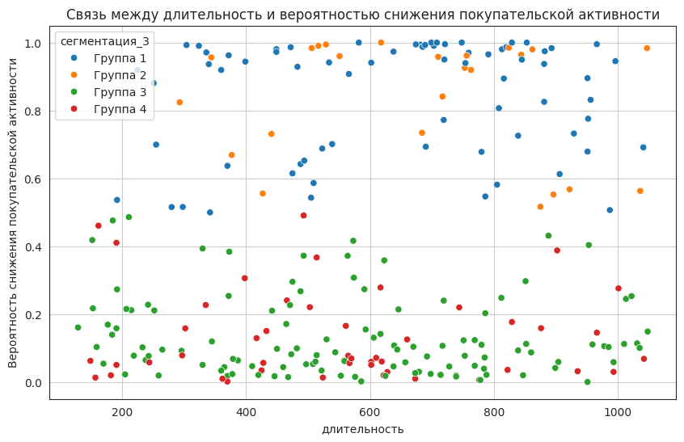

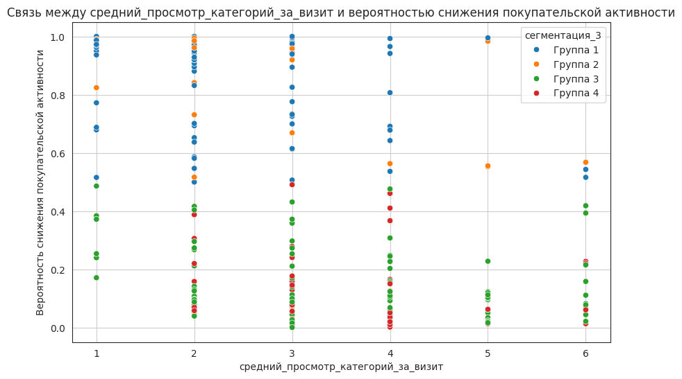

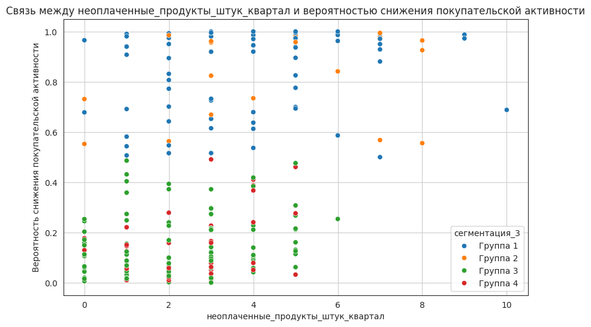

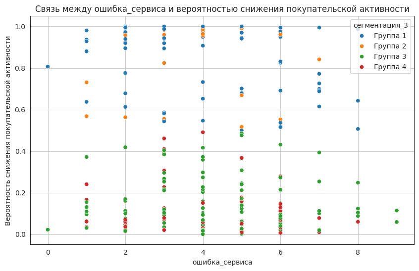

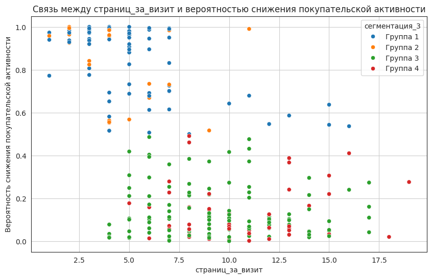

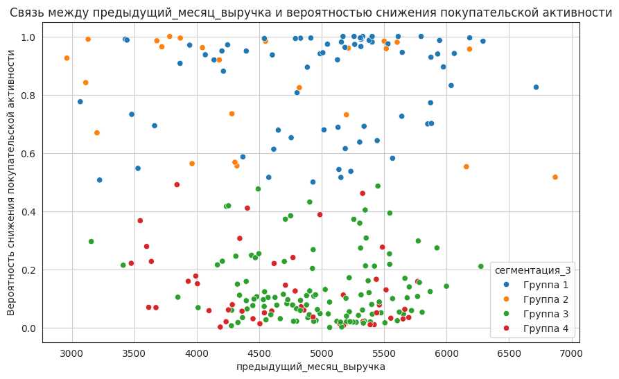

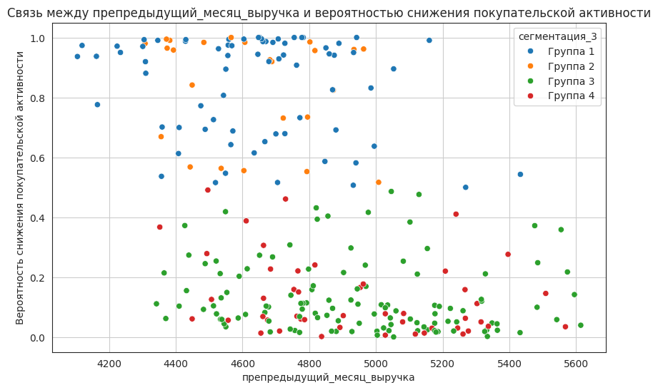

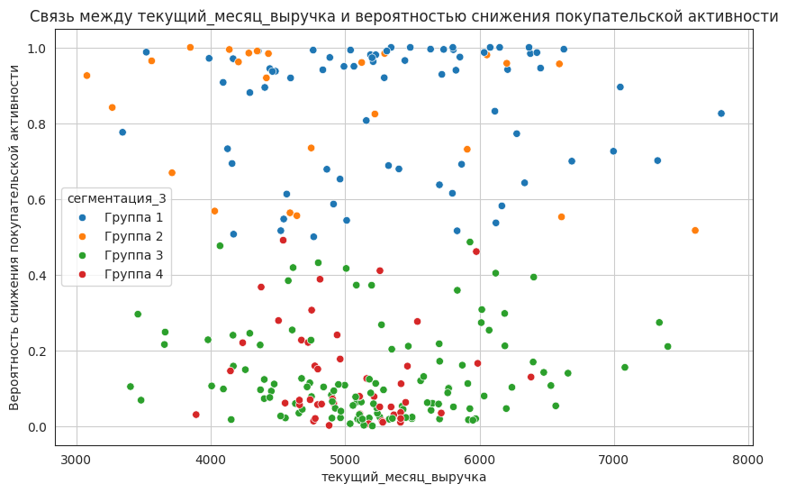

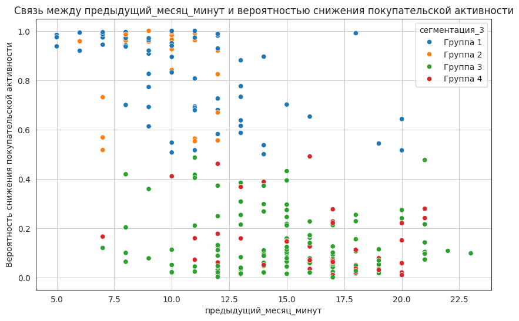

[5 more figures not shown]

```python
for column in X_test_full.select_dtypes(include=['number']).columns:
    plt.figure(figsize=(10, 6))
    sns.scatterplot(data=X_test_full, x=column, y='вероятность_снижения_покупательской_активности', hue='сегментация_3')
    plt.title(f'Связь между {column} и вероятностью снижения покупательской активности')
    plt.xlabel(column)
    plt.ylabel('Вероятность снижения покупательской активности')
    plt.grid(True)
    plt.show()
```

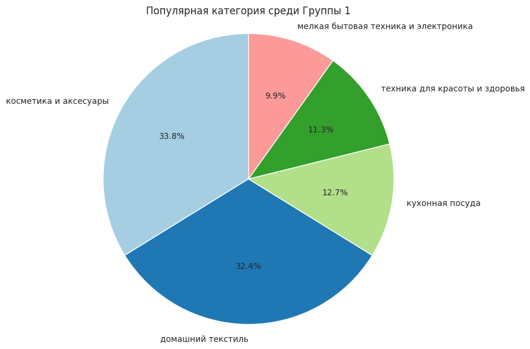

```python
plot_pie_chart(
    X_test_full.query('сегментация_3 == "Группа 1"'),
    'популярная_категория',
    'Популярная категория среди Группы 1')
```

"Товары для себя" покупает около 27% всех пользователей, в то время как "Товары для детей" - 9%.

При этом товары для детей хоть и приносят меньше выручки, но являюся более прибыльными. Разница в сегментах не такая большая, чтобы имело смысл фокусироваться только на одном из них.

Самая популярная категория товаров среди Группы 1 - "Косметика и аксессуары" и "Домашний текстиль".

#### Сегментация 4: Группа клиентов с высокой вероятностью снижения покупательской активности и наиболее высокой прибыльностью.

**Сегментация 4:**

|  | Высокая вероятность снижения активности | Низкая вероятность снижения активности |
| --- | --- | --- |
| **Высокая прибыльность** | Группа 1 | Группа 3 |
| **Низкая прибыльность** | Группа 2 | Группа 4 |

- **Группа 1:** Высокая вероятность снижения активности, высокая прибыльность.
- **Группа 2:** Высокая вероятность снижения активности, низкая прибыльность.
- **Группа 3:** Низкая вероятность снижения активности, высокая прибыльность.
- **Группа 4:** Низкая вероятность снижения активности, низкая прибыльность.

Нас интересует Группа 1.

```python
X_test_full['прибыль'].describe()
```

|  | прибыль |
| --- | --- |
| count | 260.000000 |
| mean | 3.996885 |
| std | 1.012584 |
| min | 0.860000 |
| 25% | 3.285000 |
| 50% | 4.060000 |
| 75% | 4.675000 |
| max | 6.880000 |

**dtype:** float64

К клиентом, приносящих высокую прибыль отнесем верхний квартиль.

```python
def segnmentation_4(row):
    """
    Определяет группу сегментации на основе вероятности снижения покупательской активности
    и уровня прибыли по сравнению с 75-м процентилем прибыли в тестовом наборе данных.

    Параметры:
    row: объект Series (например, строка DataFrame), содержащий данные о клиенте,
         включая вероятность снижения покупательской активности и уровень прибыли.

    Возвращает:
    str: Название группы ('Группа 1', 'Группа 2', 'Группа 3' или 'Группа 4').
    """

    # Проверяем, превышает ли вероятность снижения покупательской активности 0.5
    if row['вероятность_снижения_покупательской_активности'] >= 0.5:
        # Если вероятность высокая и прибыль выше или равна 75-му процентилю
        if row['прибыль'] >= X_test_full['прибыль'].describe()['75%']:
            return 'Группа 1'  # Группа для клиентов с высокой вероятностью снижения активности и высокой прибылью
        else:
            return 'Группа 2'  # Группа для клиентов с высокой вероятностью, но с низкой прибылью
    else:
        # Если вероятность ниже 0.5 и прибыль выше или равна 75-му процентилю
        if row['прибыль'] >= X_test_full['прибыль'].describe()['75%']:
            return 'Группа 3'  # Группа для клиентов с низкой вероятностью снижения активности и высокой прибылью
        else:
            return 'Группа 4'  # Группа для клиентов с низкой вероятностью и низкой прибылью
```

```python
X_test_full['сегментация_4'] = X_test_full.apply(segnmentation_4, axis=1)
```

```python
# СОставим таблицу с финансовой статистикой по каждой группе
segment_4_stats = X_test_full.groupby('сегментация_4')[['препредыдущий_месяц_выручка',
       'предыдущий_месяц_выручка', 'текущий_месяц_выручка', 'прибыль']].mean()
```

```python
# Добавляем долю пользователей в результирующую таблицу
segment_4_stats['доля_пользователей'] = segment_4_stats.index.map(X_test_full['сегментация_4'].value_counts(normalize=True))
```

```python
segment_4_stats
```

| сегментация_4 | препредыдущий_месяц_выручка | предыдущий_месяц_выручка | текущий_месяц_выручка | прибыль | доля_пользователей |
| --- | --- | --- | --- | --- | --- |
| Группа 1 | 4620.304348 | 4713.565217 | 4959.717391 | 5.203478 | 0.088462 |
| Группа 2 | 4638.430556 | 4929.402778 | 5318.048611 | 3.658472 | 0.276923 |
| Группа 3 | 4860.190476 | 4876.392857 | 5187.990476 | 5.284762 | 0.161538 |
| Группа 4 | 4960.056911 | 4907.544715 | 5150.782114 | 3.529593 | 0.473077 |